# Adult Mortality in the Metropolis of London 1100–1850: a Bayesian View Based on Osteological Data

Supplement: Code structure, data source and processing

Nils Müller-Scheeßel[^1]

Katharina Fuchs[^2]

Christoph Rinne[^3]

25. Juli 2024

# Prerequisites

The calculations were made in R using R-Studio. The structure of the code is essentially based on the structure of the text. The raw code is in the file `order_of_code.R`. The file extended with Markdown is `order_of_code-doc.RMD` and the file `order_of_code-doc.html` is generated from it.

Note: The base path for rmd files is the folder in which they are located, not the r-project. Consequently, `order_of_code.R` and `order_of_code-doc.RMD` are both located in the root folder of the project.

> Depending on the hardware, the subsequent code can run for several hours or even a few days.

> Install “Just Another Gibbs Sampler” (JAGS) (Plummer, 2003) if you want to run the Bayesian analyses anew. Version 4.3 - as used here - can be downloaded in pre-compiled form for a number of OS here: https://sourceforge.net/projects/mcmc-jags/ . The manual can be found here: https://people.stat.sc.edu/hansont/stat740/jags_user_manual.pdf

The code makes extensive use of the function `source` to call external code. Thus, the main part of the code remains slim, well structured and readable.

Install required packages, set some options and link the sources for the helper functions.

Remark: Depending on your R version the package osmplotr may be installed from github using `devtools::install_github ("ropensci/osmplotr")`.

```r
require(pacman) || install.packages("pacman")
```

```
## [1] TRUE
```

```r
pacman::p_load(coda, cowplot, demogR, dplyr, flexsurv, ggplot2, ggrepel, grid,
               gridExtra, HMDHFDplus, kableExtra, Metrics, mortAAR, osmdata,
               psych, readxl, reshape2, rjags, runjags, sf, tidyr, ggspatial)

options(scipen = 999)
options(dplyr.summarise.inform = FALSE)

source("./functions/gomp_MLE.R")
source("./functions/gomp_MLE_adapted.R")
source("./functions/gomp_MLE_interval.R")
source("./functions/gomp_anthr_age.R")
source("./functions/gomp_anthr_age_r.R")
source("./functions/gomp_known_age.R")
source("./functions/gomp_known_age_r.R")
source("./functions/helper_functions.R")
source("./functions/lt_MC.R")
source("./functions/lt_MC_Gomp.R")
RNGkind("L'Ecuyer-CMRG") # conservative random number generator to avoid periodicity
```

Important for saving time: Decide to run extensive code anew (app. 6 h +). In addition, you can set the folder for preprocessed files.

```r
runCodeNew <- FALSE
#runCodeNew <- TRUE

# Ask for credentials of the Human Mortality Database if the code runs anew
if (runCodeNew){
  HMD_username <- readline(prompt = "Enter username: ")
  HMD_password <- readline(prompt="Enter password: ")
  credentials <- c(HMD_username, HMD_password)
}

# Specify filename prefix for saved files and create a folder if needed:
saveFileDir = "preprocessed_files"
if (saveFileDir %in% list.files(getwd())) {
  # Dir exists
}else{
  dir.create(file.path(".", saveFileDir), showWarnings = FALSE )
}
```

# Chapter 01 Introduction

### Figure 1: Exemplary life table curves generated by Gompertz functions with different values for the $\beta$ parameter.

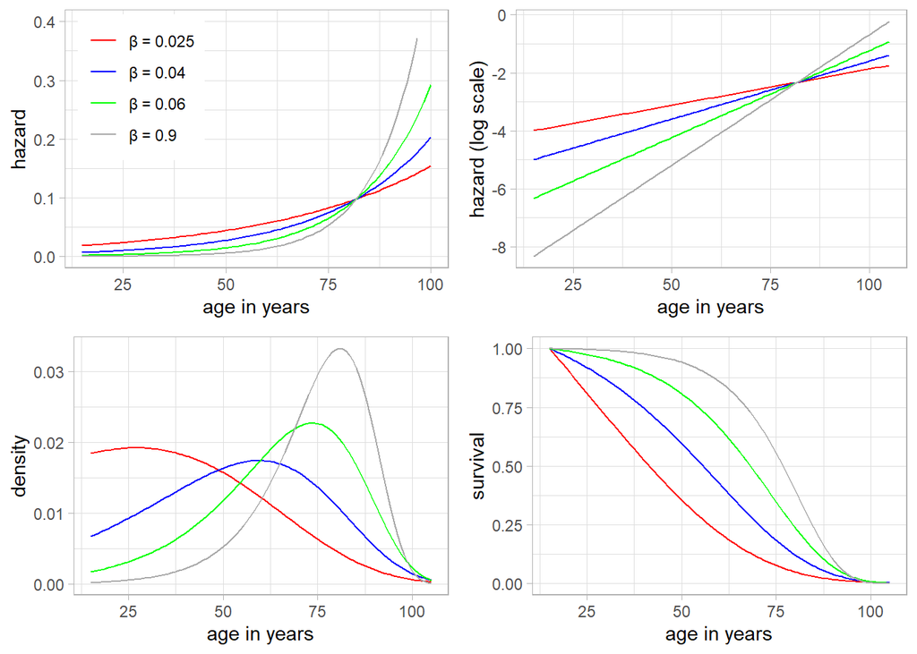

```r
# beta model values
beta1 <- 0.025
beta2 <- 0.04
beta3 <- 0.06
beta4 <- 0.09

# hgompertz(x, shape, rate):
# x = age, shape = beta value, rate = derived from Sasaki & Kondo 2016 fig. 1, 2
# rate values according Sasaki & Kondo 2016 fig. 1, line 6, 30
Sab <- -2.624
Sbb <- 0.0393
Ma <- -7.119
Mb <- 0.0718
M1 <- Sab * (beta1 - Mb) / Sbb + Ma
M2 <- Sab * (beta2 - Mb) / Sbb + Ma
M3 <- Sab * (beta3 - Mb) / Sbb + Ma
M4 <- Sab * (beta4 - Mb) / Sbb + Ma

gridExtra::grid.arrange (

  ggplot()  + xlim(15, 100) + ylim(0, 0.4) +
    geom_function(fun = function(x) flexsurv::hgompertz(x - 15, 0.025, exp(M1)),
                  aes(col = "\u03B2 = 0.025")) +
    geom_function(fun = function(x) flexsurv::hgompertz(x - 15, 0.04, exp(M2)),
                  aes(col = "\u03B2 = 0.04")) +
    geom_function(fun = function(x) flexsurv::hgompertz(x - 15, 0.06, exp(M3)),
                  aes(col = "\u03B2 = 0.06")) +
    geom_function(fun = function(x) flexsurv::hgompertz(x - 15, 0.09, exp(M4)),
                  aes(col = "\u03B2 = 0.9")) +
    ylab("hazard") + xlab("age in years") +
    theme_light() +
    scale_colour_manual(values = c("red","blue","green", "dark grey")) +
    theme(legend.position = c(0.2, 0.7), legend.title = element_blank()),

  ggplot() + xlim(15, 105) +
    geom_function(fun = function(x) log(flexsurv::hgompertz(x - 15, 0.025, exp(M1))),
                  colour = "red") +
    geom_function(fun = function(x) log(flexsurv::hgompertz(x - 15, 0.04, exp(M2))),
                  colour= "blue") +
    geom_function(fun = function(x) log(flexsurv::hgompertz(x - 15, 0.06, exp(M3))),
                  colour= "green") +
    geom_function(fun = function(x) log(flexsurv::hgompertz(x - 15, 0.09, exp(M4))),
                  colour= "dark grey") +
    xlab("age in years") + ylab("hazard (log scale)") +
    theme_light(),

  ggplot() + xlim(15, 105) +
    geom_function(fun = function(x) flexsurv::dgompertz(x - 15, 0.025, exp(M1)),
                  colour = "red") +
    geom_function(fun = function(x) flexsurv::dgompertz(x - 15, 0.04, exp(M2)),
                  colour= "blue") +
    geom_function(fun = function(x) flexsurv::dgompertz(x - 15, 0.06, exp(M3)),
                  colour= "green") +
    geom_function(fun = function(x) flexsurv::dgompertz(x - 15, 0.09, exp(M4)),
                  colour= "dark grey") +
    xlab("age in years")  + ylab("density") +
    theme_light(),

  # gomp_lx() s. functions\helper_functions.R
  ggplot() + xlim(15, 105) + ylim(0, 1) +
    geom_function(fun = function(x) gomp_lx(x - 15, exp(M1), 0.025),
                  colour = "red") +
    geom_function(fun = function(x) gomp_lx(x - 15, exp(M2), 0.04),
                  colour = "blue") +
    geom_function(fun = function(x) gomp_lx(x - 15, exp(M3), 0.06),
                  colour = "green") +
    geom_function(fun = function(x) gomp_lx(x - 15, exp(M4), 0.09),
                  colour = "dark grey") +
    ylab("survival") + xlab("age in years") +
    theme_light(),

  ncol = 2
) -> gompertz_plot
```

```r
# Save the finished map object
ggsave(
  filename = "fig01_gompertz_plot.pdf",
  width = 8, height = 6,
  plot = gompertz_plot,
  device = cairo_pdf,
  path = "documented"
)
```

# Chapter 02 Materials and methods

### Figure 2: Hazard curve (mx) for HMD UK data of the year 1841.

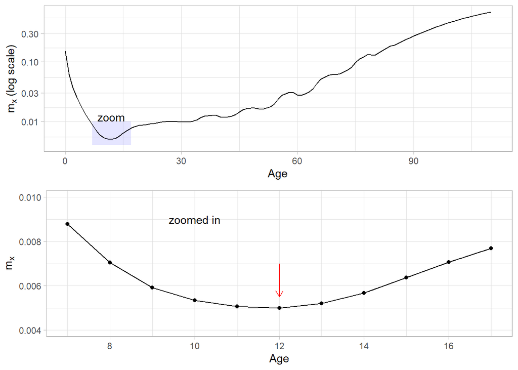

```r
# Login needed to retrieve data from the Human Mortality Database
# https://mortality.org/

if (runCodeNew){
  login <- askYesNo(paste("Login for Human Mortality Database needed.",
                          "Do you want to proceed?", sep = "\n"),
                    default = FALSE)
  # get dx
  if (login){
    HMD_UK_result_1_year <- HMDHFDplus::readHMDweb("GBRTENW", "bltper_1x1",
                                                   credentials[1],
                                                   credentials[2])

    # saves results in Rda-object
    save(HMD_UK_result_1_year, file = file.path(".", saveFileDir,
                                                "HMD_UK_result_1_year.Rda") )
  }
} else {load(file.path(".", saveFileDir, "HMD_UK_result_1_year.Rda") )
  }


gridExtra::grid.arrange(
  ggplot(HMD_UK_result_1_year[which(HMD_UK_result_1_year$Year == 1841),]) +
    geom_line(aes(x = Age, y = mx)) +
    scale_y_continuous(trans='log10') + labs(y = expression(m[x] * " (log scale)")) +
    annotate("rect", xmin = 7, xmax = 17, ymin = 0.004, ymax = 0.01,
             alpha = .1,fill = "blue") +
    annotate (geom = "text", x = 12, y = 0.012, label = "zoom") +
    theme_light(),
  ggplot(HMD_UK_result_1_year[which(HMD_UK_result_1_year$Year == 1841),],
         aes(x = Age, y = mx)) + scale_x_continuous(breaks=seq(8,16,2),
                                                    limits=c(7, 17))  +
    geom_line() + geom_point() +
    ylim(0.004, 0.01) +
    labs(y = expression(m[x]))+
    annotate (geom = "text", x = 10, y = 0.009, label = "zoomed in") +
    geom_segment(aes(x = 12, y = 0.007, xend = 12, yend = 0.0055),
                 arrow = arrow(length = unit(0.25, "cm")), colour = "red") +
    theme_light(),
  ncol = 1
) -> HMD_UK_hazard_plot
```

```r
# Save the finished map object
ggsave(
  filename = "fig03_HMD_UK_hazard_plot.pdf",
  plot = HMD_UK_hazard_plot,
  device = "pdf",
  path = "documented"
)
```

# Chapter 03 Data

### Figure 3: Major cemeteries in Greater London 1100–1850 used in the present study.

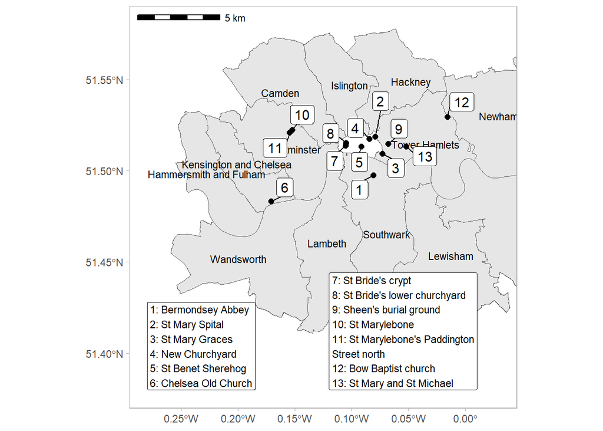

```r
# Get the coordinates of sites to be plotted
sites_data <- rbind.data.frame(
    c("1","Bermondsey Abbey", 51.4975,-0.080833),
    c("2", "St Mary Spital", 51.518716, -0.079161),
    c("3","St Mary Graces",51.509289,-0.072916 ),
    c("4", "New Churchyard", 51.517403, -0.084216),
    c("5","St Benet Sherehog",51.513194,-0.091389),
    c("6", "Chelsea Old Church", 51.483222, -0.170795),
    c("7","St Bride's crypt",51.513802,-0.105292),
    c("8", "St Bride's lower churchyard", 51.515253, -0.104973),
    c("9", "Sheen's burial ground", 51.51480, -0.06760),
    c("10","St Marylebone", 51.5225,-0.152222),
    c("11",paste("St Marylebone's Paddington", "Street north", sep="\n"),
      51.520869, -0.154515),
    c("12", "Bow Baptist church", 51.529540, -0.01580),
    c("13", "St Mary and St Michael", 51.51330, -0.05190)
  )
colnames(sites_data) <-c("nr", "name", "lat", "lon")
sites_data$lat<-as.numeric(sites_data$lat)
sites_data$lon<-as.numeric(sites_data$lon)

dat_sites <- st_as_sf(sites_data,
                      coords = c("lon", "lat"),
                      crs = 4326)

# Build a bounding box by the coordinates + 10% of the extent as frame
bbox <- matrix(
  c(
    min(sites_data$lon) - (0.1*(max(sites_data$lon)- min(sites_data$lon))),
    min(sites_data$lat) - (0.1*(max(sites_data$lat)- min(sites_data$lat))),
    max(sites_data$lon) + (0.1*(max(sites_data$lon)- min(sites_data$lon))),
    max(sites_data$lat) + (0.1*(max(sites_data$lat)- min(sites_data$lat)))
  ),
  byrow = FALSE, nrow = 2, ncol = 2,
  dimnames = list(c('x','y'),c('min','max'))
)

# Querry the osm data
# If the bbox has been changed please run the statement to get the new osm data.

if (!exists ("q_admin8") | (runCodeNew == TRUE)) {
  q_admin8 <- bbox %>% opq() %>%
    add_osm_feature(key = "boundary", value = "administrative") %>%
    add_osm_feature(key = "admin_level", value = "8") %>%
    osmdata_sf()
  }

# Build the map
London_map <- ggplot() +
  geom_sf(data = q_admin8$osm_multipolygons, fill=rgb(0.9,0.9,0.9)) +
  geom_sf_text(data = q_admin8$osm_multipolygons, aes(label=sub('.*of ','',name)),
               size=3) +
  geom_sf(data = dat_sites,aes(), shape = 16, colour = "black", size = 2) +
  ggrepel::geom_label_repel(data = dat_sites, aes(label = nr, geometry = geometry),
  stat = "sf_coordinates", min.segment.length = 0, size=4) +
  annotate("label", x = -0.28, y = 51.38, hjust = 0, vjust = 0, size = 3,
                    label = paste(apply(sites_data[1:6,1:2],1,paste,collapse = ": "),
                         collapse = "\n")) +
  annotate("label", x = -0.12, y = 51.38, hjust = 0, vjust = 0, size = 3,
           label = paste(apply(sites_data[7:13,1:2],1,paste,collapse = ": "),
                         collapse = "\n")) +
  xlim (-0.28, 0.03) +
  ylim (51.38,51.58) +
  theme_light() +
  theme(panel.grid = element_blank()) +
  theme(axis.title = element_blank()) +
  ggspatial::annotation_scale(location = 'tl', height= unit(0.15, "cm"))
plot(London_map)
```

```r
# Save the finished map object
ggsave(
  filename = "fig04_london_map.pdf",
  plot = London_map,
  device = "pdf",
  path = "documented"
)
```

```r
read.table("chapter_03_data/london_cemeteries.txt", header = T, sep = "\t") %>%
  knitr::kable(., col.names = c("Map no.",  "Name", "Period",   "Excavation year",
                                "Social character", "Absolute n",   "n analysed",
                                "n >= 12 years",    "References")) %>%
  kableExtra::kable_styling(latex_options = "HOLD_position") %>% unclass() %>% cat()
```

| Map no. | Name | Period | Excavation year | Social character | Absolute n | n analysed | n >= 12 years | References |
| --- | --- | --- | --- | --- | --- | --- | --- | --- |
| 1 | Bermondsey Abbey | 1089–1538 | 1984–1995 | monks | 208 | 201 | 201 | Dyson, Samuel, Steele, & Wright (2011) |
| 2 | St Mary Spital | 1120–1538 | 1991–2007 | commoners | 10,516 | 5,387 |  | Connell, Gray Jones, Redfern, & Walker (2012) |
| NA |  | period 14: 1120–1200 |  |  |  | 347 | 329 |  |
| NA |  | period 15: 1200–1250 |  |  |  | 510 | 470 |  |
| NA |  | period 16: 1250–1400 |  |  |  | 1,392 | 1,361 |  |
| NA |  | period 17: 1400–1539 |  |  |  | 526 | 467 |  |
| 3 | St Mary Graces | 1350–1540 | 1986–1988 | commoners |  | 378 | 298 | Grainger & Phillpotts (2011) |
| 4 | New Churchyard | 1569–1739 | 2011–2015 | low status | 3,354 | 682 (category A) | 556 | Hartle, Carty, Henderson, Knox, & Walker (2017) |
| 5 | St Benet Sherehog | 1670–1740 | 1994–1996 | higher status |  | 230 | 179 | Miles, White, & Tankard (2008) |
| 6 | Chelsea Old church | 1712–1842 | 2000 | mixed |  | 198 | 168 | Cowie, Bekvalac, & Kausmally (2008) |
| 7 | St Brides crypt | 1740–1853 |  | high |  |  | 216 | J. L. Scheuer (1995); L. Scheuer (1998) |
| 8 | St Brides lower churchyard | 1770–1849 |  | low |  | 606 | 379 | Kausmally (2008) |
| 9 | Sheens burial ground | 1763–1853 | 2006–2007 | low | 265 | 254 | 172 | Henderson, Miles, & Walker (2013) |
| 10 | St Marylebone | 1767–1859 | 1992; 2003 | high status |  | 301 | 226 | Miles, Powers, Wroe-Brown, & Walker (2008) |
| 11 | St Marylebone Paddington Street north | 1772–1853 | 2012–2013 | high status | 385 | 291 | 232 | Henderson, Walker, & Miles (2015) |
| 12 | Bow Baptist church | 1816–1853 | 2006; 2008 | villagers | 440 | 416 | 231 | Henderson et al. (2013) |
| 13 | St Mary and St Michaels burial ground | 1843–1854 | 2004–2005 | low, Irish immigrants | 760 | 705 | 284 | Henderson et al. (2013) |

### Figure 4: Population development of London, compiled from Finlay & Shearer (1986), 39 table 1; Landers (1993), 41; 179 table 5.7; Weinreb, Hibbert, Keay, & Keay (2008), 655–657.

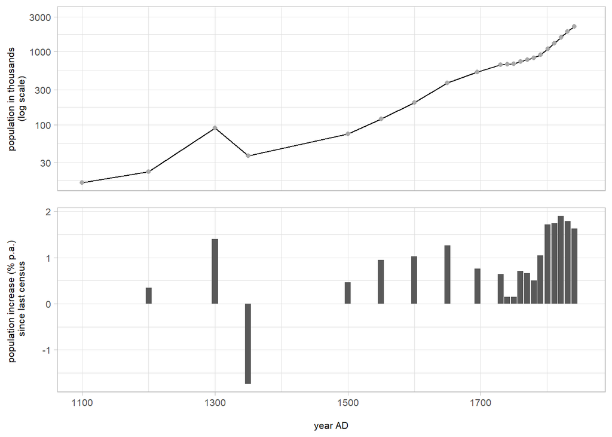

```r
source("./chapter_03_data/London_population.R")
grid::grid.newpage()
grid::grid.draw(rbind(london_pop1, london_pop2))
```

### Footnote 6: Re-calculation of population increase rates of London from Razzell & Spence (2007).

Calculated in ./chapter_03_data/London_population.R

```r
knitr::kable(razz_df)%>%
  kableExtra::kable_styling(latex_options = "HOLD_position")
```

| date | population | rate.per.year |
| --- | --- | --- |
| 1520 | 55000 | NA |
| 1600 | 200000 | 0.016 |
| 1650 | 400000 | 0.014 |
| 1700 | 575000 | 0.007 |
| 1750 | 675000 | 0.003 |
| 1801 | 960000 | 0.007 |
| 1851 | 2685000 | 0.021 |

# Chapter 04 Results

## Simulations

### Figure 5: Comparing observed and estimated Gompertz $\beta$-values by different algorithms with known age-at-death (n = 1,000).

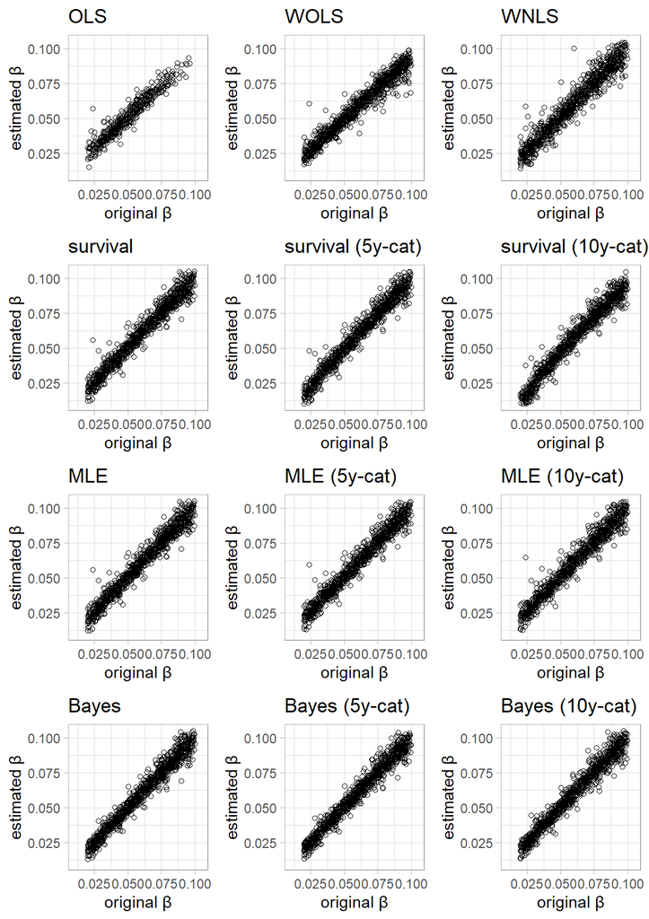

```r
source("./chapter_supplement/simulations_run.R")
gridExtra::grid.arrange(grobs = plot_list_shapes, ncol = 3)
```

### Figure 6: Difference between observed and estimated Gompertz $\beta$-values by different algorithms with known age-at-death (n = 1,000).

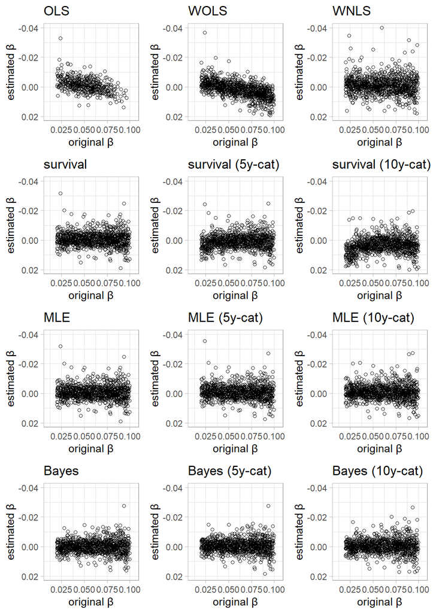

```r
source("./chapter_supplement/simulations_run.R")
gridExtra::grid.arrange(grobs = plot_list_diff, ncol = 3)
```

### Table 2: Root mean square errors (RMSE) for different formulas for fitting known age-at-death, in ascending order.

```r
# table of RMSEs
kable(rmse_result[order(rmse_result$RMSE) ,]) %>%
  kableExtra::kable_styling(latex_options = "HOLD_position")
```

|  | method | RMSE | NAs |
| --- | --- | --- | --- |
| 11 | Bayes (5y-cat) | 0.0045054 | 0 |
| 10 | Bayes | 0.0045342 | 0 |
| 7 | MLE | 0.0047464 | 0 |
| 4 | survival | 0.0047465 | 0 |
| 12 | Bayes (10y-cat) | 0.0048206 | 0 |
| 8 | MLE (5y-cat) | 0.0048251 | 0 |
| 5 | survival (5y-cat) | 0.0048980 | 0 |
| 1 | OLS | 0.0049008 | 545 |
| 9 | MLE (10y-cat) | 0.0051441 | 0 |
| 2 | WOLS | 0.0060401 | 0 |
| 3 | WNLS | 0.0061083 | 14 |
| 6 | survival (10y-cat) | 0.0067095 | 0 |

### Figure 7: Comparison of methods to estimate the original Gompertz $\beta$ from simulated data with anthropological age categories (n = 1,000).

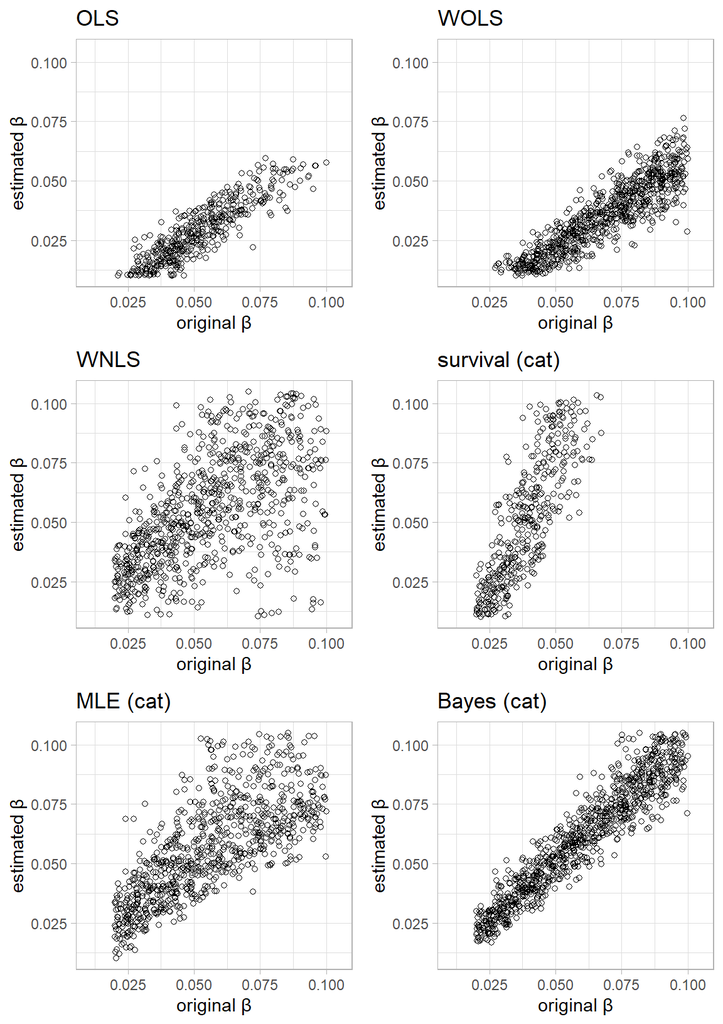

```r
source("./chapter_supplement/simulations_run.R")
gridExtra::grid.arrange(grobs = plot_list_estim_shapes, ncol = 2)
```

### Table 3: Root mean square errors in different methods to estimate the original Gompertz $\beta$ from simulated data with anthropological age categories, in ascending order.

```r
# table of RMSEs
kable(rmse_estim_result[order(rmse_estim_result$RMSE) ,]) %>%
  kableExtra::kable_styling(latex_options = "HOLD_position")
```

|  | method | RMSE | NAs |
| --- | --- | --- | --- |
| 6 | Bayes (cat) | 0.0099026 | 0 |
| 7 | MLE_wo_OL | 0.0202114 | 71 |
| 1 | OLS | 0.0243214 | 442 |
| 3 | WNLS | 0.0293842 | 73 |
| 2 | WOLS | 0.0328083 | 2 |
| 5 | MLE (cat) | 0.0761568 | 0 |
| 4 | survival (cat) | 0.4731442 | 0 |

## Written sources

Preprocessing of data used in figure 9: Estimated modal ages.

### Basic statistics

The data is referenced and aggregated in “./chapter_04_results/historical_lifetables.R”. In this file, all records from individual preprocessing files located in “./liftables_preprocessed/” are `sourced`. The corresponding data files are stored in “./data/”.

London_1728_1840.R, Mortality_bills_1728_1840.txt, Source: Roberts & Cox (2003), 304 Table 6.5; > 100 years and < 1 year collapsed

```r
source("./chapter_04_results/historical_lifetables.R")
kable(london_1728_1840_ranges,
      caption = "London Mortality bills 1728-1840.") %>%
  kableExtra::kable_styling(latex_options = "HOLD_position")
```

London Mortality bills 1728-1840.

| parameter | ranges |
| --- | --- |
| beta | 0.0324-0.0419 |
| M | 43.4-54.8 |

```r
kable(london_1728_1840_ranges_r,
      caption = "London Mortality bills 1728-1840, corrected for population growth.") %>%
  kableExtra::kable_styling(latex_options = "HOLD_position")
```

London Mortality bills 1728-1840, corrected for population growth.

| parameter | ranges |
| --- | --- |
| beta_r | 0.0327-0.0501 |
| M_r | 45.1-64.4 |
| r | 0.002-0.019 |

London_1841_raw_all.R, London_1841_raw.txt, Source: Graham (1842), 19 table q.

```r
kable(London_1841_ranges,
      caption = "Census data for London from 1841.") %>%
  kableExtra::kable_styling(latex_options = "HOLD_position")
```

Census data for London from 1841.

| parameter | modes | HDI.ranges |
| --- | --- | --- |
| beta | 0.0547 | 0.0510-0.0585 |
| M | 60.4164 | 58.9-61.7 |

English_Mortality.R, wrigley_et_al_1997_england_1640-1809.txt, Source: Wrigley, Oeppen, Davies, & Schofield (1997), 290 table 6.19

```r
kable(eng_mort_ranges,
      caption = "English mortality data.") %>%
  kableExtra::kable_styling(latex_options = "HOLD_position")
```

English mortality data.

| parameter | ranges |
| --- | --- |
| beta | 0.0438-0.0608 |
| M | 52.2-67.4 |

HMD_UK_ranges.R

The data from the Human Mortality Database (https://mortality.org/) were retrieved with a personal account using the R package HMDHFDplus. Therefore, we only provide the processed data here.

```r
kable(HMD_UK_ranges, caption = "Human Mortality Database UK.") %>%
  kableExtra::kable_styling(latex_options = "HOLD_position")
```

Human Mortality Database UK.

| parameter | ranges |
| --- | --- |
| beta | 0.05-0.0654 |
| M | 64.2-70.2 |

English_Peers.R, russell.txt, Source: La Poutré & Janssen (2021), table 2

```r
kable(peers_ranges, caption = "English Peers") %>%
  kableExtra::kable_styling(latex_options = "HOLD_position")
```

English Peers

| parameter | modes | HDI.ranges |
| --- | --- | --- |
| beta | 0.0613 | 0.0559-0.0660 |
| M | 58.1758 | 56.4-59.8 |
| e20 | 33.4148 | NA |
| e25 | 29.4926 | NA |

Medieval_England.R, Christ_church_monks.txt, Source: Hatcher, Piper, & Stone (2006), 28 table 2

```r
kable(monks_ranges, caption = "Christ Church monks") %>%
  kableExtra::kable_styling(latex_options = "HOLD_position")
```

Christ Church monks

| parameter | modes | HDI.ranges |
| --- | --- | --- |
| beta | 0.0461 | 0.0398-0.0523 |
| M | 52.7659 | 48.9-56.0 |
| e20 | 31.0948 | NA |
| e25 | 27.7530 | NA |

### Extended statistics

```r
kable(london_1728_1840_result,
      caption = "London Mortality bills 1728-1840.") %>%
  kableExtra::kable_styling(latex_options = c("HOLD_position","scale_down"))
```

London Mortality bills 1728-1840.

| year | parameter | PSRF Point est. | PSRF Upper C.I. | Mean | Median | Mode | ESS | MCSE | HDImass | HDIlow | HDIhigh |
| --- | --- | --- | --- | --- | --- | --- | --- | --- | --- | --- | --- |
| X1728 | alpha | 1.000108 | 1.000395 | 0.0146970 | 0.0146465 | 0.0145984 | 16365.6 | 0.0000105 | 0.95 | 0.0121552 | 0.0173894 |
| X1728 | beta | 1.000120 | 1.000451 | 0.0349080 | 0.0349052 | 0.0347825 | 16828.8 | 0.0000207 | 0.95 | 0.0296327 | 0.0401025 |
| X1728 | M | 1.000140 | 1.000453 | 44.6140062 | 44.8625026 | 45.0618057 | 16114.3 | 0.0233898 | 0.95 | 38.7086866 | 50.1735217 |
| X1730 | alpha | 1.000025 | 1.000130 | 0.0156646 | 0.0156056 | 0.0154789 | 18337.2 | 0.0000111 | 0.95 | 0.0127633 | 0.0186414 |
| X1730 | beta | 1.000039 | 1.000168 | 0.0325426 | 0.0325361 | 0.0324144 | 18117.0 | 0.0000207 | 0.95 | 0.0270931 | 0.0379764 |
| X1730 | M | 1.000030 | 1.000142 | 42.2093093 | 42.5573739 | 43.4233691 | 18020.2 | 0.0277785 | 0.95 | 34.7516415 | 49.0050848 |
| X1740 | alpha | 1.000112 | 1.000403 | 0.0153878 | 0.0153418 | 0.0152749 | 17990.7 | 0.0000100 | 0.95 | 0.0128087 | 0.0180175 |
| X1740 | beta | 1.000101 | 1.000385 | 0.0337646 | 0.0337606 | 0.0335736 | 17926.6 | 0.0000190 | 0.95 | 0.0288006 | 0.0387511 |
| X1740 | M | 1.000157 | 1.000484 | 43.0932517 | 43.3416150 | 44.0450446 | 17518.4 | 0.0233112 | 0.95 | 36.9618783 | 48.8486639 |
| X1750 | alpha | 1.000308 | 1.001170 | 0.0151942 | 0.0151449 | 0.0150989 | 18259.5 | 0.0000101 | 0.95 | 0.0125952 | 0.0179004 |
| X1750 | beta | 1.000351 | 1.001292 | 0.0342717 | 0.0342730 | 0.0342242 | 18121.9 | 0.0000195 | 0.95 | 0.0290667 | 0.0393662 |
| X1750 | M | 1.000317 | 1.001174 | 43.5548106 | 43.8136623 | 44.5458564 | 17813.4 | 0.0230371 | 0.95 | 37.3772875 | 49.2243556 |
| X1760 | alpha | 1.000338 | 1.000801 | 0.0145711 | 0.0145269 | 0.0143509 | 17449.6 | 0.0000100 | 0.95 | 0.0120404 | 0.0171711 |
| X1760 | beta | 1.000241 | 1.000520 | 0.0350287 | 0.0350196 | 0.0349168 | 17085.2 | 0.0000201 | 0.95 | 0.0299236 | 0.0402371 |
| X1760 | M | 1.000363 | 1.000866 | 44.8827829 | 45.1095653 | 45.6086874 | 17106.4 | 0.0221726 | 0.95 | 39.1055721 | 50.2653901 |
| X1770 | alpha | 1.000175 | 1.000588 | 0.0143221 | 0.0142774 | 0.0142718 | 17407.1 | 0.0000099 | 0.95 | 0.0117796 | 0.0169045 |
| X1770 | beta | 1.000110 | 1.000381 | 0.0355969 | 0.0356004 | 0.0358743 | 17291.4 | 0.0000203 | 0.95 | 0.0304311 | 0.0408902 |
| X1770 | M | 1.000178 | 1.000591 | 45.4300281 | 45.6462299 | 45.7955369 | 17214.1 | 0.0214852 | 0.95 | 39.8417826 | 50.7260430 |
| X1780 | alpha | 1.000269 | 1.000935 | 0.0136238 | 0.0135783 | 0.0135358 | 16804.1 | 0.0000095 | 0.95 | 0.0112248 | 0.0160214 |
| X1780 | beta | 1.000239 | 1.000906 | 0.0367220 | 0.0367253 | 0.0367228 | 16729.5 | 0.0000201 | 0.95 | 0.0317062 | 0.0419311 |
| X1780 | M | 1.000314 | 1.001006 | 46.8874156 | 47.0760558 | 47.5932925 | 16847.5 | 0.0195467 | 0.95 | 41.7873949 | 51.6004245 |
| X1790 | alpha | 1.000213 | 1.000318 | 0.0126517 | 0.0126141 | 0.0126627 | 16987.5 | 0.0000089 | 0.95 | 0.0103904 | 0.0149291 |
| X1790 | beta | 1.000153 | 1.000189 | 0.0385170 | 0.0385078 | 0.0385633 | 16735.7 | 0.0000203 | 0.95 | 0.0333069 | 0.0435894 |
| X1790 | M | 1.000247 | 1.000390 | 48.8232330 | 48.9686652 | 49.3336238 | 17313.3 | 0.0172234 | 0.95 | 44.3303384 | 53.1112910 |
| X1800 | alpha | 1.000066 | 1.000135 | 0.0116898 | 0.0116448 | 0.0115679 | 15913.4 | 0.0000085 | 0.95 | 0.0096159 | 0.0138219 |
| X1800 | beta | 1.000108 | 1.000229 | 0.0399437 | 0.0399437 | 0.0398114 | 16280.5 | 0.0000202 | 0.95 | 0.0348971 | 0.0449998 |
| X1800 | M | 1.000048 | 1.000103 | 50.7070955 | 50.8409969 | 51.0720614 | 16902.5 | 0.0156219 | 0.95 | 46.6498010 | 54.5415198 |
| X1810 | alpha | 1.000554 | 1.001977 | 0.0115040 | 0.0114672 | 0.0113409 | 15693.3 | 0.0000082 | 0.95 | 0.0095496 | 0.0135586 |
| X1810 | beta | 1.000705 | 1.002539 | 0.0384284 | 0.0384204 | 0.0384387 | 15514.8 | 0.0000196 | 0.95 | 0.0336019 | 0.0431446 |
| X1810 | M | 1.000514 | 1.001824 | 51.3269015 | 51.4533360 | 51.7564282 | 16513.8 | 0.0160886 | 0.95 | 47.1307998 | 55.1816194 |
| X1820 | alpha | 1.000033 | 1.000085 | 0.0104903 | 0.0104573 | 0.0103834 | 15105.4 | 0.0000079 | 0.95 | 0.0086455 | 0.0124121 |
| X1820 | beta | 1.000043 | 1.000117 | 0.0403661 | 0.0403518 | 0.0400258 | 14941.4 | 0.0000204 | 0.95 | 0.0354922 | 0.0452322 |
| X1820 | M | 1.000026 | 1.000068 | 53.3477816 | 53.4500376 | 53.7200147 | 16242.5 | 0.0145904 | 0.95 | 49.6159817 | 56.8461806 |
| X1830 | alpha | 1.000262 | 1.000742 | 0.0098565 | 0.0098250 | 0.0097444 | 14287.5 | 0.0000077 | 0.95 | 0.0080915 | 0.0116937 |
| X1830 | beta | 1.000328 | 1.000824 | 0.0420331 | 0.0420192 | 0.0419423 | 14811.9 | 0.0000207 | 0.95 | 0.0371686 | 0.0470269 |
| X1830 | M | 1.000204 | 1.000597 | 54.4845443 | 54.5690888 | 54.8316675 | 16013.8 | 0.0134579 | 0.95 | 51.1240793 | 57.7697242 |
| X1840 | alpha | 1.000065 | 1.000175 | 0.0103000 | 0.0102638 | 0.0101621 | 14542.4 | 0.0000080 | 0.95 | 0.0084719 | 0.0122192 |
| X1840 | beta | 1.000062 | 1.000189 | 0.0409226 | 0.0409164 | 0.0407728 | 14161.3 | 0.0000212 | 0.95 | 0.0360077 | 0.0458839 |
| X1840 | M | 1.000053 | 1.000143 | 53.6798657 | 53.7773975 | 53.7555529 | 15909.8 | 0.0144310 | 0.95 | 50.0411401 | 57.1294679 |

```r
kable(london_1728_1840_result_r,
      caption = "London Mortality bills 1728-1840, corrected for population growth.") %>%
  kableExtra::kable_styling(latex_options = c("HOLD_position","scale_down"))
```

London Mortality bills 1728-1840, corrected for population growth.

| year | parameter | PSRF Point est. | PSRF Upper C.I. | Mean | Median | Mode | ESS | MCSE | HDImass | HDIlow | HDIhigh |
| --- | --- | --- | --- | --- | --- | --- | --- | --- | --- | --- | --- |
| X1728 | alpha | 1.000493 | 1.001271 | 0.0120388 | 0.0119639 | 0.0117705 | 13219.2 | 0.0000127 | 0.95 | 0.0092381 | 0.0149068 |
| X1728 | beta | 1.000293 | 1.000781 | 0.0373256 | 0.0373497 | 0.0374499 | 14626.6 | 0.0000261 | 0.95 | 0.0312018 | 0.0435282 |
| X1728 | M | 1.000607 | 1.001494 | 50.2038587 | 50.4495217 | 50.9806000 | 13687.7 | 0.0264982 | 0.95 | 43.9280763 | 55.9188957 |
| X1728 | rate | 1.000147 | 1.000459 | 0.0066686 | 0.0066694 | 0.0067571 | 27227.8 | 0.0000151 | 0.95 | 0.0018302 | 0.0116186 |
| X1730 | alpha | 1.000269 | 1.000770 | 0.0148858 | 0.0147951 | 0.0145680 | 14694.8 | 0.0000148 | 0.95 | 0.0115075 | 0.0185145 |
| X1730 | beta | 1.000150 | 1.000455 | 0.0324320 | 0.0324651 | 0.0327068 | 16554.5 | 0.0000253 | 0.95 | 0.0260065 | 0.0387515 |
| X1730 | M | 1.000349 | 1.000914 | 43.6813384 | 44.1622266 | 45.0521696 | 14720.2 | 0.0375115 | 0.95 | 34.6717649 | 52.0836240 |
| X1730 | rate | 1.000125 | 1.000492 | 0.0017597 | 0.0017647 | 0.0017560 | 31387.5 | 0.0000140 | 0.95 | -0.0031019 | 0.0066355 |
| X1740 | alpha | 1.000329 | 1.000720 | 0.0146610 | 0.0145783 | 0.0142673 | 12838.5 | 0.0000145 | 0.95 | 0.0115556 | 0.0179785 |
| X1740 | beta | 1.000371 | 1.001036 | 0.0338783 | 0.0339015 | 0.0340453 | 14559.4 | 0.0000244 | 0.95 | 0.0281672 | 0.0397172 |
| X1740 | M | 1.000313 | 1.000633 | 44.5110399 | 44.8625313 | 45.6855802 | 12927.7 | 0.0334910 | 0.95 | 36.8686339 | 51.5460098 |
| X1740 | rate | 1.000079 | 1.000225 | 0.0015451 | 0.0015464 | 0.0015893 | 25927.1 | 0.0000155 | 0.95 | -0.0033455 | 0.0064169 |
| X1750 | alpha | 1.000091 | 1.000301 | 0.0126650 | 0.0125920 | 0.0124096 | 13381.2 | 0.0000131 | 0.95 | 0.0097778 | 0.0156841 |
| X1750 | beta | 1.000158 | 1.000520 | 0.0363874 | 0.0364000 | 0.0364127 | 15055.2 | 0.0000254 | 0.95 | 0.0303579 | 0.0425971 |
| X1750 | M | 1.000109 | 1.000338 | 48.8679712 | 49.1288156 | 49.6582623 | 13657.6 | 0.0280568 | 0.95 | 42.3123463 | 55.0499366 |
| X1750 | rate | 1.000002 | 1.000003 | 0.0061501 | 0.0061570 | 0.0061586 | 28511.9 | 0.0000148 | 0.95 | 0.0012302 | 0.0110002 |
| X1760 | alpha | 1.000046 | 1.000138 | 0.0118787 | 0.0118090 | 0.0117666 | 13167.5 | 0.0000125 | 0.95 | 0.0091035 | 0.0146849 |
| X1760 | beta | 1.000017 | 1.000101 | 0.0375028 | 0.0375223 | 0.0376118 | 15087.9 | 0.0000254 | 0.95 | 0.0314240 | 0.0436194 |
| X1760 | M | 1.000075 | 1.000168 | 50.5533524 | 50.7836185 | 51.6251396 | 13738.2 | 0.0259954 | 0.95 | 44.4208165 | 56.2002552 |
| X1760 | rate | 1.000014 | 1.000079 | 0.0068523 | 0.0068519 | 0.0068244 | 26661.9 | 0.0000153 | 0.95 | 0.0019504 | 0.0117469 |
| X1770 | alpha | 1.000380 | 1.001203 | 0.0121911 | 0.0121201 | 0.0120472 | 13162.6 | 0.0000128 | 0.95 | 0.0093360 | 0.0150793 |
| X1770 | beta | 1.000576 | 1.001801 | 0.0375407 | 0.0375624 | 0.0378417 | 14253.2 | 0.0000262 | 0.95 | 0.0314411 | 0.0437422 |
| X1770 | M | 1.000298 | 1.000964 | 49.8528284 | 50.0817560 | 50.3580496 | 13551.1 | 0.0264695 | 0.95 | 43.7540998 | 55.7240017 |
| X1770 | rate | 1.000094 | 1.000275 | 0.0053016 | 0.0052956 | 0.0052041 | 27499.5 | 0.0000151 | 0.95 | 0.0004322 | 0.0101881 |
| X1780 | alpha | 1.001089 | 1.003872 | 0.0100912 | 0.0100242 | 0.0098793 | 13153.1 | 0.0000107 | 0.95 | 0.0077807 | 0.0125681 |
| X1780 | beta | 1.000765 | 1.002770 | 0.0407636 | 0.0407668 | 0.0406275 | 14796.3 | 0.0000251 | 0.95 | 0.0347108 | 0.0466753 |
| X1780 | M | 1.001100 | 1.003857 | 54.2249121 | 54.3794171 | 54.9416590 | 14389.5 | 0.0204589 | 0.95 | 49.2715760 | 58.8762349 |
| X1780 | rate | 1.000574 | 1.002146 | 0.0098681 | 0.0098605 | 0.0099363 | 27001.6 | 0.0000152 | 0.95 | 0.0049838 | 0.0147621 |
| X1790 | alpha | 1.001213 | 1.004101 | 0.0075877 | 0.0075309 | 0.0073853 | 13394.6 | 0.0000085 | 0.95 | 0.0057156 | 0.0095457 |
| X1790 | beta | 1.000912 | 1.003290 | 0.0458236 | 0.0458462 | 0.0458421 | 14781.8 | 0.0000260 | 0.95 | 0.0396890 | 0.0520899 |
| X1790 | M | 1.001011 | 1.003327 | 59.2913458 | 59.3690803 | 59.3913393 | 16477.9 | 0.0152745 | 0.95 | 55.4175368 | 63.1058941 |
| X1790 | rate | 1.000444 | 1.001551 | 0.0163690 | 0.0163788 | 0.0165687 | 24985.7 | 0.0000158 | 0.95 | 0.0115298 | 0.0213122 |
| X1800 | alpha | 1.000387 | 1.001251 | 0.0067681 | 0.0067205 | 0.0066553 | 12952.0 | 0.0000077 | 0.95 | 0.0050763 | 0.0085024 |
| X1800 | beta | 1.000332 | 1.001184 | 0.0477523 | 0.0477522 | 0.0478150 | 14065.9 | 0.0000260 | 0.95 | 0.0416756 | 0.0537888 |
| X1800 | M | 1.000285 | 1.000812 | 60.9817744 | 61.0368872 | 61.0870784 | 17235.5 | 0.0136042 | 0.95 | 57.4198438 | 64.4259602 |
| X1800 | rate | 1.000109 | 1.000405 | 0.0172752 | 0.0172792 | 0.0173804 | 24208.7 | 0.0000160 | 0.95 | 0.0123856 | 0.0221662 |
| X1810 | alpha | 1.000202 | 1.000668 | 0.0062540 | 0.0062051 | 0.0060517 | 12219.0 | 0.0000076 | 0.95 | 0.0046618 | 0.0079061 |
| X1810 | beta | 1.000300 | 1.000974 | 0.0466685 | 0.0466843 | 0.0466222 | 13819.9 | 0.0000264 | 0.95 | 0.0405736 | 0.0527045 |
| X1810 | M | 1.000099 | 1.000312 | 63.1437477 | 63.1965586 | 63.1840070 | 16815.0 | 0.0141963 | 0.95 | 59.5131108 | 66.7201334 |
| X1810 | rate | 1.000063 | 1.000170 | 0.0186911 | 0.0186887 | 0.0186977 | 21565.1 | 0.0000171 | 0.95 | 0.0138016 | 0.0236117 |
| X1820 | alpha | 1.000215 | 1.000279 | 0.0057095 | 0.0056649 | 0.0055172 | 11737.7 | 0.0000072 | 0.95 | 0.0042407 | 0.0072573 |
| X1820 | beta | 1.000270 | 1.000463 | 0.0488446 | 0.0488583 | 0.0489581 | 12730.0 | 0.0000279 | 0.95 | 0.0425629 | 0.0548806 |
| X1820 | M | 1.000058 | 1.000058 | 64.0351053 | 64.0783090 | 64.1736064 | 17185.5 | 0.0129582 | 0.95 | 60.6476942 | 67.3084873 |
| X1820 | rate | 1.000055 | 1.000145 | 0.0183072 | 0.0183033 | 0.0183194 | 21399.3 | 0.0000171 | 0.95 | 0.0134475 | 0.0232238 |
| X1830 | alpha | 1.000851 | 1.002718 | 0.0056217 | 0.0055807 | 0.0055025 | 11196.7 | 0.0000071 | 0.95 | 0.0041951 | 0.0071180 |
| X1830 | beta | 1.000811 | 1.002726 | 0.0500179 | 0.0500137 | 0.0501418 | 12016.8 | 0.0000281 | 0.95 | 0.0440217 | 0.0561384 |
| X1830 | M | 1.000547 | 1.001650 | 63.7874764 | 63.8285439 | 63.9588124 | 16675.9 | 0.0124725 | 0.95 | 60.5930623 | 66.9110171 |
| X1830 | rate | 1.000415 | 1.001353 | 0.0169139 | 0.0169158 | 0.0170653 | 21735.5 | 0.0000169 | 0.95 | 0.0119901 | 0.0217235 |
| X1840 | alpha | 1.001912 | 1.006772 | 0.0055618 | 0.0055194 | 0.0053917 | 11400.5 | 0.0000071 | 0.95 | 0.0040979 | 0.0070495 |
| X1840 | beta | 1.001683 | 1.006126 | 0.0496698 | 0.0496734 | 0.0495466 | 12494.4 | 0.0000281 | 0.95 | 0.0435270 | 0.0558486 |
| X1840 | M | 1.001165 | 1.004232 | 64.1728612 | 64.2122002 | 64.4409872 | 16778.0 | 0.0127460 | 0.95 | 60.9228836 | 67.4118054 |
| X1840 | rate | 1.000770 | 1.002796 | 0.0184375 | 0.0184351 | 0.0184647 | 20471.4 | 0.0000175 | 0.95 | 0.0135561 | 0.0233655 |

```r
kable(London_1841_result,
      caption = "Census data for London from 1841.") %>%
  kableExtra::kable_styling(latex_options = c("HOLD_position","scale_down"))
```

Census data for London from 1841.

|  | PSRF Point est. | PSRF Upper C.I. | Mean | Median | Mode | ESS | MCSE | HDImass | HDIlow | HDIhigh |
| --- | --- | --- | --- | --- | --- | --- | --- | --- | --- | --- |
| a | 1.000227 | 1.000481 | 0.0045780 | 0.0045654 | 0.0045126 | 15366.4 | 0.0000030 | 0.95 | 0.0038745 | 0.0053284 |
| b | 1.000173 | 1.000361 | 0.0547652 | 0.0547581 | 0.0546507 | 15261.7 | 0.0000155 | 0.95 | 0.0510256 | 0.0585294 |
| M | 1.000098 | 1.000288 | 60.3512664 | 60.3640713 | 60.4164328 | 26323.3 | 0.0044223 | 0.95 | 58.9378882 | 61.7484732 |

```r
kable(eng_mort_result, caption = "English mortality data.") %>%
  kableExtra::kable_styling(latex_options = c("HOLD_position","scale_down"))
```

English mortality data.

| year | parameter | PSRF Point est. | PSRF Upper C.I. | Mean | Median | Mode | ESS | MCSE | HDImass | HDIlow | HDIhigh |
| --- | --- | --- | --- | --- | --- | --- | --- | --- | --- | --- | --- |
| X1640 | alpha | 1.000116 | 1.000213 | 0.0109640 | 0.0109440 | 0.0108724 | 20086.8 | 0.0000055 | 0.95 | 0.0094508 | 0.0125183 |
| X1640 | beta | 1.000128 | 1.000269 | 0.0473794 | 0.0473646 | 0.0471615 | 19457.0 | 0.0000160 | 0.95 | 0.0430271 | 0.0517521 |
| X1640 | M | 1.000098 | 1.000168 | 55.8790864 | 55.9257645 | 56.0762781 | 22766.9 | 0.0074788 | 0.95 | 53.6542245 | 58.0607633 |
| X1650 | alpha | 1.000196 | 1.000699 | 0.0086495 | 0.0086305 | 0.0086386 | 17477.0 | 0.0000050 | 0.95 | 0.0073694 | 0.0099516 |
| X1650 | beta | 1.000238 | 1.000818 | 0.0534298 | 0.0534191 | 0.0532174 | 17097.8 | 0.0000176 | 0.95 | 0.0488730 | 0.0579356 |
| X1650 | M | 1.000122 | 1.000456 | 59.0892102 | 59.1180884 | 59.1222939 | 22875.6 | 0.0058105 | 0.95 | 57.3707403 | 60.8059797 |
| X1660 | alpha | 1.000538 | 1.001899 | 0.0091323 | 0.0091133 | 0.0090836 | 17736.5 | 0.0000051 | 0.95 | 0.0078190 | 0.0104985 |
| X1660 | beta | 1.000442 | 1.001588 | 0.0507107 | 0.0507012 | 0.0506517 | 17263.0 | 0.0000172 | 0.95 | 0.0463039 | 0.0551739 |
| X1660 | M | 1.000484 | 1.001711 | 58.8100849 | 58.8427992 | 58.8427140 | 22595.3 | 0.0063824 | 0.95 | 56.9061034 | 60.6611103 |
| X1670 | alpha | 1.000280 | 1.000678 | 0.0109726 | 0.0109471 | 0.0109033 | 20090.3 | 0.0000056 | 0.95 | 0.0094600 | 0.0125515 |
| X1670 | beta | 1.000338 | 1.000812 | 0.0444972 | 0.0445019 | 0.0446316 | 19399.7 | 0.0000157 | 0.95 | 0.0402542 | 0.0488448 |
| X1670 | M | 1.000211 | 1.000529 | 56.4443366 | 56.5061422 | 56.5992418 | 22544.4 | 0.0083487 | 0.95 | 53.9239107 | 58.8183187 |
| X1680 | alpha | 1.000560 | 1.001531 | 0.0134499 | 0.0134251 | 0.0133309 | 22339.5 | 0.0000061 | 0.95 | 0.0116869 | 0.0152420 |
| X1680 | beta | 1.000479 | 1.001399 | 0.0435646 | 0.0435605 | 0.0437501 | 21337.1 | 0.0000151 | 0.95 | 0.0392159 | 0.0478531 |
| X1680 | M | 1.000597 | 1.001611 | 51.9412993 | 52.0117614 | 52.1884363 | 23152.8 | 0.0091727 | 0.95 | 49.1667363 | 54.6014009 |
| X1690 | alpha | 1.000203 | 1.000424 | 0.0100036 | 0.0099815 | 0.0099278 | 19068.4 | 0.0000053 | 0.95 | 0.0085828 | 0.0114492 |
| X1690 | beta | 1.000217 | 1.000487 | 0.0457255 | 0.0457144 | 0.0457837 | 18458.1 | 0.0000160 | 0.95 | 0.0414631 | 0.0499716 |
| X1690 | M | 1.000156 | 1.000323 | 58.2265512 | 58.2748183 | 58.3311613 | 22552.3 | 0.0076819 | 0.95 | 55.9044003 | 60.4191960 |
| X1700 | alpha | 1.000247 | 1.000813 | 0.0097904 | 0.0097696 | 0.0097670 | 19048.9 | 0.0000052 | 0.95 | 0.0083976 | 0.0112137 |
| X1700 | beta | 1.000228 | 1.000792 | 0.0469162 | 0.0469091 | 0.0468449 | 18524.9 | 0.0000160 | 0.95 | 0.0426635 | 0.0512282 |
| X1700 | M | 1.000210 | 1.000697 | 58.3940436 | 58.4388608 | 58.4010030 | 22362.5 | 0.0073779 | 0.95 | 56.2165699 | 60.5292073 |
| X1710 | alpha | 1.000629 | 1.002202 | 0.0076344 | 0.0076175 | 0.0075883 | 16583.9 | 0.0000046 | 0.95 | 0.0064833 | 0.0088178 |
| X1710 | beta | 1.000810 | 1.002798 | 0.0547320 | 0.0547184 | 0.0547561 | 16149.3 | 0.0000181 | 0.95 | 0.0502213 | 0.0592441 |
| X1710 | M | 1.000354 | 1.001230 | 61.0059909 | 61.0278089 | 61.0396872 | 23904.2 | 0.0053119 | 0.95 | 59.3643989 | 62.5807876 |
| X1720 | alpha | 1.000438 | 1.001584 | 0.0080028 | 0.0079824 | 0.0079301 | 17173.5 | 0.0000047 | 0.95 | 0.0068173 | 0.0092105 |
| X1720 | beta | 1.000453 | 1.001645 | 0.0560063 | 0.0560001 | 0.0558861 | 16622.0 | 0.0000179 | 0.95 | 0.0514205 | 0.0604697 |
| X1720 | M | 1.000297 | 1.001094 | 59.7548666 | 59.7785061 | 59.8227855 | 23615.5 | 0.0051845 | 0.95 | 58.1648789 | 61.2877274 |
| X1730 | alpha | 1.000128 | 1.000485 | 0.0067962 | 0.0067781 | 0.0067500 | 15125.2 | 0.0000045 | 0.95 | 0.0057413 | 0.0078882 |
| X1730 | beta | 1.000132 | 1.000481 | 0.0561362 | 0.0561233 | 0.0561525 | 14537.5 | 0.0000193 | 0.95 | 0.0516431 | 0.0607418 |
| X1730 | M | 1.000086 | 1.000325 | 62.6345173 | 62.6558894 | 62.6742840 | 23395.6 | 0.0050475 | 0.95 | 61.1122439 | 64.1406077 |
| X1740 | alpha | 1.000185 | 1.000678 | 0.0067863 | 0.0067674 | 0.0067507 | 15383.6 | 0.0000045 | 0.95 | 0.0057019 | 0.0078702 |
| X1740 | beta | 1.000260 | 1.000953 | 0.0566936 | 0.0566911 | 0.0568096 | 15043.4 | 0.0000191 | 0.95 | 0.0520709 | 0.0612724 |
| X1740 | M | 1.000063 | 1.000245 | 62.4655115 | 62.4849711 | 62.4345863 | 22893.7 | 0.0051037 | 0.95 | 60.9419302 | 63.9688404 |
| X1750 | alpha | 1.000389 | 1.001407 | 0.0053793 | 0.0053645 | 0.0053635 | 13451.8 | 0.0000040 | 0.95 | 0.0044682 | 0.0062959 |
| X1750 | beta | 1.000443 | 1.001627 | 0.0595510 | 0.0595305 | 0.0594825 | 12966.5 | 0.0000210 | 0.95 | 0.0548610 | 0.0642515 |
| X1750 | M | 1.000167 | 1.000607 | 65.4071998 | 65.4213962 | 65.4642394 | 24607.7 | 0.0044311 | 0.95 | 64.0354191 | 66.7582250 |
| X1760 | alpha | 1.000180 | 1.000387 | 0.0080565 | 0.0080378 | 0.0079359 | 17802.8 | 0.0000047 | 0.95 | 0.0068516 | 0.0092887 |
| X1760 | beta | 1.000187 | 1.000346 | 0.0488550 | 0.0488417 | 0.0488743 | 16840.4 | 0.0000169 | 0.95 | 0.0445037 | 0.0531121 |
| X1760 | M | 1.000119 | 1.000328 | 61.9016665 | 61.9336352 | 62.0050035 | 23618.5 | 0.0063598 | 0.95 | 59.9327761 | 63.7618010 |
| X1770 | alpha | 1.000469 | 1.001234 | 0.0067654 | 0.0067476 | 0.0066997 | 14881.8 | 0.0000045 | 0.95 | 0.0057073 | 0.0078687 |
| X1770 | beta | 1.000501 | 1.001341 | 0.0538935 | 0.0538804 | 0.0536262 | 14373.8 | 0.0000192 | 0.95 | 0.0494452 | 0.0584665 |
| X1770 | M | 1.000270 | 1.000709 | 63.5277738 | 63.5489910 | 63.4921572 | 22585.6 | 0.0054864 | 0.95 | 61.9173469 | 65.1383522 |
| X1780 | alpha | 1.000347 | 1.001235 | 0.0066384 | 0.0066225 | 0.0066110 | 15713.1 | 0.0000043 | 0.95 | 0.0055976 | 0.0076907 |
| X1780 | beta | 1.000349 | 1.001303 | 0.0570824 | 0.0570677 | 0.0571475 | 15127.7 | 0.0000188 | 0.95 | 0.0526292 | 0.0616896 |
| X1780 | M | 1.000195 | 1.000710 | 62.7166530 | 62.7352113 | 62.7235429 | 24154.0 | 0.0048243 | 0.95 | 61.2201635 | 64.1540268 |
| X1790 | alpha | 1.000180 | 1.000376 | 0.0058127 | 0.0057951 | 0.0057825 | 13899.0 | 0.0000042 | 0.95 | 0.0048677 | 0.0068164 |
| X1790 | beta | 1.000229 | 1.000478 | 0.0580897 | 0.0580826 | 0.0579337 | 13447.1 | 0.0000206 | 0.95 | 0.0533856 | 0.0627649 |
| X1790 | M | 1.000055 | 1.000174 | 64.6577738 | 64.6756380 | 64.7246120 | 23430.8 | 0.0047208 | 0.95 | 63.2361972 | 66.0657933 |
| X1800 | alpha | 1.000697 | 1.002167 | 0.0046142 | 0.0045977 | 0.0045567 | 12391.5 | 0.0000037 | 0.95 | 0.0038253 | 0.0054317 |
| X1800 | beta | 1.000709 | 1.002222 | 0.0608363 | 0.0608357 | 0.0608310 | 11940.3 | 0.0000219 | 0.95 | 0.0561091 | 0.0654678 |
| X1800 | M | 1.000239 | 1.000822 | 67.4325112 | 67.4451148 | 67.4486965 | 26907.8 | 0.0039816 | 0.95 | 66.1359322 | 68.6958522 |

```r
kable(HMD_UK_result, caption = "Human Mortality Database UK.") %>%
  kableExtra::kable_styling(latex_options = c("HOLD_position","scale_down"))
```

Human Mortality Database UK.

| year | parameter | PSRF Point est. | PSRF Upper C.I. | Mean | Median | Mode | ESS | MCSE | HDImass | HDIlow | HDIhigh |
| --- | --- | --- | --- | --- | --- | --- | --- | --- | --- | --- | --- |
| X1841 | alpha | 1.000163 | 1.000417 | 0.0036316 | 0.0036148 | 0.0035704 | 13786.9 | 0.0000032 | 0.95 | 0.0029186 | 0.0043694 |
| X1841 | beta | 1.000156 | 1.000468 | 0.0519888 | 0.0519880 | 0.0522191 | 13557.1 | 0.0000185 | 0.95 | 0.0476828 | 0.0561015 |
| X1841 | M | 1.000083 | 1.000148 | 66.2542881 | 66.2748935 | 66.3111134 | 25227.7 | 0.0056085 | 0.95 | 64.4997322 | 67.9878895 |
| X1845 | alpha | 1.000079 | 1.000297 | 0.0042938 | 0.0042780 | 0.0042669 | 14758.1 | 0.0000036 | 0.95 | 0.0034647 | 0.0051540 |
| X1845 | beta | 1.000067 | 1.000247 | 0.0498996 | 0.0498859 | 0.0500069 | 14606.7 | 0.0000180 | 0.95 | 0.0455985 | 0.0541474 |
| X1845 | M | 1.000065 | 1.000255 | 64.2120906 | 64.2353737 | 64.2258466 | 24443.1 | 0.0062539 | 0.95 | 62.2412879 | 66.0782225 |
| X1850 | alpha | 1.000973 | 1.003549 | 0.0037558 | 0.0037391 | 0.0036783 | 13963.2 | 0.0000033 | 0.95 | 0.0030110 | 0.0045196 |
| X1850 | beta | 1.000868 | 1.003159 | 0.0517607 | 0.0517548 | 0.0515669 | 13902.2 | 0.0000185 | 0.95 | 0.0475374 | 0.0561228 |
| X1850 | M | 1.000670 | 1.002447 | 65.7445767 | 65.7656894 | 65.8470383 | 24788.4 | 0.0057544 | 0.95 | 63.9683713 | 67.5152044 |
| X1855 | alpha | 1.000156 | 1.000325 | 0.0034310 | 0.0034165 | 0.0034148 | 13071.2 | 0.0000031 | 0.95 | 0.0027387 | 0.0041407 |
| X1855 | beta | 1.000111 | 1.000252 | 0.0533405 | 0.0533264 | 0.0532089 | 12901.9 | 0.0000193 | 0.95 | 0.0489858 | 0.0575821 |
| X1855 | M | 1.000055 | 1.000176 | 66.5070750 | 66.5214941 | 66.5377049 | 24496.9 | 0.0055156 | 0.95 | 64.7810996 | 68.1628553 |
| X1860 | alpha | 1.000103 | 1.000169 | 0.0034785 | 0.0034615 | 0.0034062 | 13432.3 | 0.0000031 | 0.95 | 0.0027794 | 0.0041924 |
| X1860 | beta | 1.000118 | 1.000200 | 0.0532621 | 0.0532640 | 0.0532106 | 13350.6 | 0.0000189 | 0.95 | 0.0490210 | 0.0575846 |
| X1860 | M | 1.000016 | 1.000032 | 66.2956647 | 66.3134949 | 66.3500169 | 24949.1 | 0.0054798 | 0.95 | 64.5756127 | 67.9675086 |
| X1865 | alpha | 1.000093 | 1.000333 | 0.0035991 | 0.0035837 | 0.0035330 | 13810.1 | 0.0000031 | 0.95 | 0.0028932 | 0.0043267 |
| X1865 | beta | 1.000108 | 1.000353 | 0.0530530 | 0.0530491 | 0.0530859 | 13658.1 | 0.0000185 | 0.95 | 0.0488013 | 0.0572954 |
| X1865 | M | 1.000045 | 1.000177 | 65.7780212 | 65.7953467 | 65.8802464 | 25507.4 | 0.0054316 | 0.95 | 64.0717897 | 67.4665740 |
| X1870 | alpha | 1.000077 | 1.000191 | 0.0035027 | 0.0034908 | 0.0034765 | 13760.3 | 0.0000030 | 0.95 | 0.0028292 | 0.0042127 |
| X1870 | beta | 1.000110 | 1.000242 | 0.0536849 | 0.0536587 | 0.0535650 | 13616.9 | 0.0000184 | 0.95 | 0.0495385 | 0.0579499 |
| X1870 | M | 1.000013 | 1.000070 | 65.9071237 | 65.9205478 | 65.8577523 | 25746.8 | 0.0052524 | 0.95 | 64.2645935 | 67.5678728 |
| X1875 | alpha | 1.000092 | 1.000343 | 0.0030605 | 0.0030478 | 0.0030211 | 12815.0 | 0.0000028 | 0.95 | 0.0024475 | 0.0036823 |
| X1875 | beta | 1.000131 | 1.000471 | 0.0568401 | 0.0568279 | 0.0568980 | 12685.7 | 0.0000193 | 0.95 | 0.0526071 | 0.0611415 |
| X1875 | M | 1.000031 | 1.000141 | 66.4668857 | 66.4785272 | 66.5086127 | 26537.0 | 0.0047162 | 0.95 | 64.9506366 | 67.9602202 |
| X1880 | alpha | 1.000119 | 1.000291 | 0.0027376 | 0.0027242 | 0.0026867 | 12292.1 | 0.0000026 | 0.95 | 0.0021904 | 0.0033047 |
| X1880 | beta | 1.000171 | 1.000388 | 0.0580794 | 0.0580802 | 0.0580583 | 12275.9 | 0.0000195 | 0.95 | 0.0538930 | 0.0623071 |
| X1880 | M | 1.000016 | 1.000046 | 67.6639684 | 67.6752899 | 67.6594434 | 26763.5 | 0.0045057 | 0.95 | 66.2138218 | 69.0997903 |
| X1885 | alpha | 1.000329 | 1.000699 | 0.0024297 | 0.0024169 | 0.0023954 | 11472.9 | 0.0000024 | 0.95 | 0.0019319 | 0.0029532 |
| X1885 | beta | 1.000279 | 1.000617 | 0.0605593 | 0.0605577 | 0.0605172 | 11375.3 | 0.0000207 | 0.95 | 0.0561612 | 0.0648427 |
| X1885 | M | 1.000124 | 1.000309 | 68.1749533 | 68.1842585 | 68.1928238 | 26834.9 | 0.0042250 | 0.95 | 66.8018933 | 69.5153058 |
| X1890 | alpha | 1.000121 | 1.000451 | 0.0024118 | 0.0023997 | 0.0023802 | 11867.7 | 0.0000024 | 0.95 | 0.0019247 | 0.0029285 |
| X1890 | beta | 1.000146 | 1.000531 | 0.0614665 | 0.0614588 | 0.0613662 | 11669.1 | 0.0000205 | 0.95 | 0.0571518 | 0.0657954 |
| X1890 | M | 1.000045 | 1.000148 | 67.7519542 | 67.7613179 | 67.8037905 | 28081.6 | 0.0040695 | 0.95 | 66.4069818 | 69.0759956 |
| X1895 | alpha | 1.000328 | 1.001210 | 0.0019825 | 0.0019735 | 0.0019634 | 10586.6 | 0.0000021 | 0.95 | 0.0015598 | 0.0024219 |
| X1895 | beta | 1.000267 | 1.000994 | 0.0637922 | 0.0637712 | 0.0636859 | 10594.5 | 0.0000217 | 0.95 | 0.0594245 | 0.0681856 |
| X1895 | M | 1.000224 | 1.000819 | 69.4924393 | 69.4994274 | 69.5249671 | 28489.7 | 0.0038280 | 0.95 | 68.2103261 | 70.7410684 |
| X1900 | alpha | 1.000051 | 1.000194 | 0.0017882 | 0.0017794 | 0.0017686 | 10113.1 | 0.0000020 | 0.95 | 0.0013975 | 0.0021792 |
| X1900 | beta | 1.000061 | 1.000247 | 0.0653147 | 0.0653019 | 0.0653664 | 10036.7 | 0.0000222 | 0.95 | 0.0609626 | 0.0696771 |
| X1900 | M | 1.000007 | 1.000020 | 70.1656919 | 70.1713832 | 70.1615274 | 28126.0 | 0.0036879 | 0.95 | 68.9548389 | 71.3801825 |

```r
kable(peers_result, caption = "English Peers.") %>%
  kableExtra::kable_styling(latex_options = c("HOLD_position","scale_down"))
```

English Peers.

|  | PSRF Point est. | PSRF Upper C.I. | Mean | Median | Mode | ESS | MCSE | HDImass | HDIlow | HDIhigh |
| --- | --- | --- | --- | --- | --- | --- | --- | --- | --- | --- |
| a | 1.000356 | 1.001061 | 0.0044095 | 0.0043879 | 0.0043263 | 11315.3 | 0.0000044 | 0.95 | 0.0035238 | 0.0053575 |
| b | 1.000307 | 1.000854 | 0.0609452 | 0.0609518 | 0.0612976 | 11121.9 | 0.0000244 | 0.95 | 0.0559415 | 0.0660412 |
| M | 1.000196 | 1.000696 | 58.1500750 | 58.1648975 | 58.1757927 | 20660.4 | 0.0059675 | 0.95 | 56.4492001 | 59.8036275 |

```r
kable(monks_result, caption = "Christ Church monks.") %>%
  kableExtra::kable_styling(latex_options = c("HOLD_position","scale_down"))
```

Christ Church monks.

| start | end | parameter | PSRF Point est. | PSRF Upper C.I. | Mean | Median | Mode | ESS | MCSE | HDImass | HDIlow | HDIhigh |
| --- | --- | --- | --- | --- | --- | --- | --- | --- | --- | --- | --- | --- |
| 1395 | 1505 | alpha | 1.000569 | 1.001661 | 0.0102993 | 0.0102563 | 0.0100488 | 13991.9 | 0.0000096 | 0.95 | 0.0081076 | 0.0125497 |
| 1395 | 1505 | beta | 1.000498 | 1.001436 | 0.0459467 | 0.0459287 | 0.0461060 | 13623.6 | 0.0000273 | 0.95 | 0.0397953 | 0.0523389 |
| 1395 | 1505 | M | 1.000504 | 1.001504 | 52.5281106 | 52.6296486 | 52.7658924 | 15808.5 | 0.0143226 | 0.95 | 48.9344189 | 55.9631681 |

## London cemeteries

The data is mainly hard coded in the file ./chapter_04_results/Wellcome_DB.R.

Only St. Bride’s crypt is excluded but available from the Museum of London upon request. For general information: https://www.museumoflondon.org.uk go for: Collections > Archaeology at the Museum of London > Wellcome Osteological Research Database > St. Bride’s Church Fleet Street. If runCodeNew == TRUE the file ./lifetables_processing/stbrides_crypt.R will ask for the location of the retrieved dataset (Excel sheet) and process the data. In any other case pre-processed data will be loaded.

```r
source("./lifetables_processing/stbrides_crypt.R")
source("./chapter_04_results/Wellcome_DB.R")
```

```r
kable(wellcome_result) %>%
  kableExtra::kable_styling(latex_options = c("HOLD_position","scale_down"))
```

| cemetery | start | end | parameter | PSRF Point est. | PSRF Upper C.I. | Mean | Median | Mode | ESS | MCSE | HDImass | HDIlow | HDIhigh |
| --- | --- | --- | --- | --- | --- | --- | --- | --- | --- | --- | --- | --- | --- |
| Bermondsey Abbey | 1089 | 1538 | alpha | 1.000095 | 1.000352 | 0.0119872 | 0.0118695 | 0.0117349 | 26882.4 | 0.0000115 | 0.95 | 0.0084108 | 0.0157410 |
| Bermondsey Abbey | 1089 | 1538 | beta | 1.000115 | 1.000319 | 0.0410531 | 0.0410516 | 0.0413654 | 23098.5 | 0.0000312 | 0.95 | 0.0318561 | 0.0503895 |
| Bermondsey Abbey | 1089 | 1538 | M | 1.000071 | 1.000266 | 41.8366810 | 42.1437778 | 42.5664355 | 29309.6 | 0.0207896 | 0.95 | 34.6719658 | 48.4310632 |
| St. Mary Graces | 1350 | 1540 | alpha | 1.000196 | 1.000732 | 0.0197808 | 0.0196850 | 0.0195223 | 35662.0 | 0.0000118 | 0.95 | 0.0154857 | 0.0241619 |
| St. Mary Graces | 1350 | 1540 | beta | 1.000244 | 1.000894 | 0.0346722 | 0.0346636 | 0.0349129 | 29450.8 | 0.0000239 | 0.95 | 0.0266567 | 0.0427213 |
| St. Mary Graces | 1350 | 1540 | M | 1.000288 | 1.000951 | 27.6620555 | 28.2853721 | 29.0829030 | 31343.0 | 0.0275212 | 0.95 | 17.7908628 | 36.1544161 |
| St. Mary Hospital, 1120-1200 | 1120 | 1200 | alpha | 1.000021 | 1.000058 | 0.0249328 | 0.0248411 | 0.0247596 | 47240.6 | 0.0000108 | 0.95 | 0.0203838 | 0.0295337 |
| St. Mary Hospital, 1120-1200 | 1120 | 1200 | beta | 1.000010 | 1.000041 | 0.0363031 | 0.0363142 | 0.0366087 | 42155.0 | 0.0000184 | 0.95 | 0.0288655 | 0.0437148 |
| St. Mary Hospital, 1120-1200 | 1120 | 1200 | M | 1.000014 | 1.000048 | 21.9000883 | 22.4278307 | 23.6171674 | 41316.5 | 0.0217592 | 0.95 | 12.9358328 | 29.6933479 |
| St. Mary Hospital, 1200-1250 | 1200 | 1250 | alpha | 1.000142 | 1.000479 | 0.0299501 | 0.0298832 | 0.0296347 | 50227.8 | 0.0000103 | 0.95 | 0.0254561 | 0.0345077 |
| St. Mary Hospital, 1200-1250 | 1200 | 1250 | beta | 1.000145 | 1.000390 | 0.0356927 | 0.0356959 | 0.0355017 | 44544.0 | 0.0000163 | 0.95 | 0.0288836 | 0.0423855 |
| St. Mary Hospital, 1200-1250 | 1200 | 1250 | M | 1.000138 | 1.000388 | 16.4726206 | 16.9685941 | 17.8228768 | 43773.7 | 0.0209091 | 0.95 | 7.6941741 | 24.3391668 |
| St. Mary Hospital, 1250-1400 | 1250 | 1400 | alpha | 1.000058 | 1.000230 | 0.0183232 | 0.0182986 | 0.0182568 | 30711.1 | 0.0000060 | 0.95 | 0.0162397 | 0.0203837 |
| St. Mary Hospital, 1250-1400 | 1250 | 1400 | beta | 1.000039 | 1.000160 | 0.0580756 | 0.0580643 | 0.0577145 | 27569.9 | 0.0000162 | 0.95 | 0.0529190 | 0.0634424 |
| St. Mary Hospital, 1250-1400 | 1250 | 1400 | M | 1.000056 | 1.000226 | 31.8403051 | 31.8802975 | 31.9815271 | 32452.4 | 0.0050096 | 0.95 | 30.0460798 | 33.5688087 |
| St. Mary Hospital, 1400-1539 | 1400 | 1539 | alpha | 1.000184 | 1.000413 | 0.0262455 | 0.0261845 | 0.0258468 | 45106.6 | 0.0000098 | 0.95 | 0.0222297 | 0.0303974 |
| St. Mary Hospital, 1400-1539 | 1400 | 1539 | beta | 1.000202 | 1.000384 | 0.0374668 | 0.0374646 | 0.0373648 | 37992.2 | 0.0000178 | 0.95 | 0.0307176 | 0.0443176 |
| St. Mary Hospital, 1400-1539 | 1400 | 1539 | M | 1.000255 | 1.000509 | 21.1562579 | 21.5422484 | 22.2118499 | 38394.6 | 0.0188420 | 0.95 | 13.7317283 | 27.8355824 |
| New Churchyard | 1569 | 1739 | alpha | 1.000100 | 1.000375 | 0.0257447 | 0.0256826 | 0.0256229 | 40693.9 | 0.0000097 | 0.95 | 0.0219664 | 0.0296497 |
| New Churchyard | 1569 | 1739 | beta | 1.000143 | 1.000447 | 0.0365472 | 0.0365523 | 0.0364771 | 33659.4 | 0.0000185 | 0.95 | 0.0298776 | 0.0431955 |
| New Churchyard | 1569 | 1739 | M | 1.000167 | 1.000489 | 21.2258180 | 21.6422371 | 22.4873708 | 34065.6 | 0.0202506 | 0.95 | 13.6829257 | 27.9012158 |
| St. Benet Sherehog | 1670 | 1740 | alpha | 1.000103 | 1.000388 | 0.0159324 | 0.0158024 | 0.0157241 | 35332.7 | 0.0000126 | 0.95 | 0.0114989 | 0.0206750 |
| St. Benet Sherehog | 1670 | 1740 | beta | 1.000166 | 1.000541 | 0.0354819 | 0.0354675 | 0.0352938 | 29914.9 | 0.0000268 | 0.95 | 0.0265131 | 0.0446216 |
| St. Benet Sherehog | 1670 | 1740 | M | 1.000123 | 1.000414 | 34.0694974 | 34.7174821 | 36.0672253 | 33191.8 | 0.0286473 | 0.95 | 23.6417236 | 43.3454393 |
| Chelsea Old church | 1712 | 1842 | alpha | 1.000092 | 1.000284 | 0.0083989 | 0.0083033 | 0.0082201 | 24055.1 | 0.0000095 | 0.95 | 0.0056545 | 0.0113658 |
| Chelsea Old church | 1712 | 1842 | beta | 1.000107 | 1.000363 | 0.0422444 | 0.0421520 | 0.0421527 | 20068.2 | 0.0000343 | 0.95 | 0.0327982 | 0.0517568 |
| Chelsea Old church | 1712 | 1842 | M | 1.000066 | 1.000214 | 50.2412943 | 50.4255236 | 50.6944550 | 32126.8 | 0.0173728 | 0.95 | 43.9580757 | 56.1242381 |
| St. Marylebone | 1742 | 1817 | alpha | 1.000026 | 1.000095 | 0.0125953 | 0.0125006 | 0.0123046 | 29334.6 | 0.0000102 | 0.95 | 0.0092608 | 0.0160318 |
| St. Marylebone | 1742 | 1817 | beta | 1.000017 | 1.000034 | 0.0420937 | 0.0420895 | 0.0423370 | 23957.1 | 0.0000291 | 0.95 | 0.0331445 | 0.0508272 |
| St. Marylebone | 1742 | 1817 | M | 1.000036 | 1.000085 | 40.5179648 | 40.7766676 | 41.3760128 | 31991.5 | 0.0170220 | 0.95 | 34.3796076 | 46.1332104 |
| St. Marylebone Paddington Street north | 1772 | 1853 | alpha | 1.000045 | 1.000166 | 0.0099037 | 0.0098127 | 0.0096774 | 27403.8 | 0.0000087 | 0.95 | 0.0071709 | 0.0127837 |
| St. Marylebone Paddington Street north | 1772 | 1853 | beta | 1.000055 | 1.000206 | 0.0488613 | 0.0488575 | 0.0485839 | 23270.2 | 0.0000301 | 0.95 | 0.0398523 | 0.0578266 |
| St. Marylebone Paddington Street north | 1772 | 1853 | M | 1.000039 | 1.000116 | 44.6690555 | 44.7919466 | 45.0496301 | 37001.7 | 0.0116510 | 0.95 | 40.1953904 | 48.9817326 |
| St. Bride’s lower churchyard | 1770 | 1849 | alpha | 1.000035 | 1.000073 | 0.0061790 | 0.0061316 | 0.0059751 | 14779.1 | 0.0000071 | 0.95 | 0.0045330 | 0.0078754 |
| St. Bride’s lower churchyard | 1770 | 1849 | beta | 1.000155 | 1.000339 | 0.0510752 | 0.0510280 | 0.0511331 | 11203.6 | 0.0000422 | 0.95 | 0.0423814 | 0.0598976 |
| St. Bride’s lower churchyard | 1770 | 1849 | M | 1.000130 | 1.000460 | 53.4368072 | 53.4511152 | 53.4536777 | 46992.7 | 0.0074618 | 0.95 | 50.2090353 | 56.5697935 |
| Sheen’s burial ground | 1763 | 1854 | alpha | 1.000091 | 1.000320 | 0.0129642 | 0.0128270 | 0.0124596 | 28565.8 | 0.0000128 | 0.95 | 0.0089230 | 0.0173233 |
| Sheen’s burial ground | 1763 | 1854 | beta | 1.000171 | 1.000495 | 0.0353994 | 0.0353305 | 0.0350479 | 24673.6 | 0.0000300 | 0.95 | 0.0262620 | 0.0446735 |
| Sheen’s burial ground | 1763 | 1854 | M | 1.000120 | 1.000420 | 39.9956498 | 40.5717091 | 41.5741951 | 29050.5 | 0.0299067 | 0.95 | 29.5817256 | 49.0658033 |
| Bow Baptist Church | 1816 | 1854 | alpha | 1.000037 | 1.000121 | 0.0177742 | 0.0176655 | 0.0171967 | 37363.4 | 0.0000114 | 0.95 | 0.0135868 | 0.0221462 |
| Bow Baptist Church | 1816 | 1854 | beta | 1.000013 | 1.000063 | 0.0344658 | 0.0344556 | 0.0344680 | 30272.0 | 0.0000249 | 0.95 | 0.0259810 | 0.0429301 |
| Bow Baptist Church | 1816 | 1854 | M | 1.000031 | 1.000063 | 30.6580796 | 31.3283020 | 32.6360138 | 33171.9 | 0.0277771 | 0.95 | 20.3999444 | 39.3695617 |
| St. Mary and St. Michael | 1843 | 1853 | alpha | 1.000523 | 1.001826 | 0.0186478 | 0.0185639 | 0.0182508 | 41699.1 | 0.0000099 | 0.95 | 0.0148267 | 0.0227130 |
| St. Mary and St. Michael | 1843 | 1853 | beta | 1.000441 | 1.001467 | 0.0402140 | 0.0402172 | 0.0404972 | 35162.0 | 0.0000216 | 0.95 | 0.0322916 | 0.0481568 |
| St. Mary and St. Michael | 1843 | 1853 | M | 1.000616 | 1.001944 | 30.8426109 | 31.1889790 | 31.6656994 | 38394.2 | 0.0171194 | 0.95 | 24.1587401 | 36.9724139 |
| St. Bride’s crypt (known age) | 1740 | 1853 | alpha | 1.001301 | 1.004385 | 0.0048650 | 0.0048100 | 0.0046364 | 11054.4 | 0.0000077 | 0.95 | 0.0033513 | 0.0064885 |
| St. Bride’s crypt (known age) | 1740 | 1853 | beta | 1.001527 | 1.004999 | 0.0492998 | 0.0492831 | 0.0490777 | 10841.1 | 0.0000350 | 0.95 | 0.0422819 | 0.0564716 |
| St. Bride’s crypt (known age) | 1740 | 1853 | M | 1.000820 | 1.002819 | 59.1168993 | 59.1961001 | 59.4409448 | 16528.6 | 0.0139187 | 0.95 | 55.5069567 | 62.4858268 |
| St. Bride’s crypt (estimates) | 1740 | 1853 | alpha | 1.000667 | 1.001933 | 0.0050596 | 0.0049986 | 0.0049298 | 13764.5 | 0.0000077 | 0.95 | 0.0033634 | 0.0068603 |
| St. Bride’s crypt (estimates) | 1740 | 1853 | beta | 1.000585 | 1.001723 | 0.0462335 | 0.0461153 | 0.0454728 | 11584.8 | 0.0000403 | 0.95 | 0.0377323 | 0.0547333 |
| St. Bride’s crypt (estimates) | 1740 | 1853 | M | 1.000256 | 1.000830 | 60.0338767 | 60.0689768 | 60.0228465 | 29593.8 | 0.0137494 | 0.95 | 55.4311154 | 64.7087860 |

```r
kable(wellcome_result_r, caption = "London cemeteries data, corrected for population growth.") %>%
  kableExtra::kable_styling(latex_options = c("HOLD_position","scale_down"))
```

London cemeteries data, corrected for population growth.

| cemetery | start | end | parameter | PSRF Point est. | PSRF Upper C.I. | Mean | Median | Mode | ESS | MCSE | HDImass | HDIlow | HDIhigh |
| --- | --- | --- | --- | --- | --- | --- | --- | --- | --- | --- | --- | --- | --- |
| Bermondsey Abbey | 1089 | 1538 | alpha | 1.0004384 | 1.0015608 | 0.0100569 | 0.0099338 | 0.0097741 | 26240.3 | 0.0000109 | 0.95 | 0.0067655 | 0.0136223 |
| Bermondsey Abbey | 1089 | 1538 | beta | 1.0003921 | 1.0013937 | 0.0433703 | 0.0433773 | 0.0439068 | 23240.1 | 0.0000321 | 0.95 | 0.0336783 | 0.0528649 |
| Bermondsey Abbey | 1089 | 1538 | M | 1.0004266 | 1.0014866 | 45.6822436 | 45.8835839 | 46.3326136 | 31446.6 | 0.0191945 | 0.95 | 38.8667009 | 52.1542950 |
| Bermondsey Abbey | 1089 | 1538 | rate | 1.0000854 | 1.0002686 | 0.0056417 | 0.0056377 | 0.0056041 | 102807.2 | 0.0000078 | 0.95 | 0.0007694 | 0.0105372 |
| St. Mary Graces | 1350 | 1540 | alpha | 1.0000932 | 1.0003161 | 0.0170437 | 0.0169434 | 0.0165866 | 33968.9 | 0.0000118 | 0.95 | 0.0128337 | 0.0213373 |
| St. Mary Graces | 1350 | 1540 | beta | 1.0001339 | 1.0004049 | 0.0371500 | 0.0371640 | 0.0372066 | 29663.0 | 0.0000246 | 0.95 | 0.0288233 | 0.0454699 |
| St. Mary Graces | 1350 | 1540 | M | 1.0001704 | 1.0003953 | 32.6280813 | 33.0720564 | 34.0698466 | 31395.2 | 0.0239922 | 0.95 | 24.0736465 | 40.3502861 |
| St. Mary Graces | 1350 | 1540 | rate | 1.0000468 | 1.0001575 | 0.0050180 | 0.0050153 | 0.0049096 | 99929.5 | 0.0000079 | 0.95 | 0.0001584 | 0.0099181 |
| St. Mary Hospital, 1120-1200 | 1120 | 1200 | alpha | 1.0000497 | 1.0001475 | 0.0228863 | 0.0227945 | 0.0226674 | 43639.6 | 0.0000115 | 0.95 | 0.0183315 | 0.0276910 |
| St. Mary Hospital, 1120-1200 | 1120 | 1200 | beta | 1.0000265 | 1.0000918 | 0.0379803 | 0.0379876 | 0.0382392 | 42254.5 | 0.0000186 | 0.95 | 0.0304388 | 0.0454329 |
| St. Mary Hospital, 1120-1200 | 1120 | 1200 | M | 1.0000797 | 1.0001963 | 24.9927341 | 25.4146781 | 26.3099807 | 40134.0 | 0.0201904 | 0.95 | 16.8250371 | 32.3104430 |
| St. Mary Hospital, 1120-1200 | 1120 | 1200 | rate | 0.9999984 | 1.0000119 | 0.0028410 | 0.0028475 | 0.0030828 | 117798.6 | 0.0000072 | 0.95 | -0.0020372 | 0.0077045 |
| St. Mary Hospital, 1200-1250 | 1200 | 1250 | alpha | 1.0000343 | 1.0001359 | 0.0231140 | 0.0230386 | 0.0229749 | 51291.4 | 0.0000094 | 0.95 | 0.0190446 | 0.0273729 |
| St. Mary Hospital, 1200-1250 | 1200 | 1250 | beta | 1.0000008 | 1.0000202 | 0.0397849 | 0.0397884 | 0.0399445 | 50597.0 | 0.0000158 | 0.95 | 0.0328000 | 0.0467253 |
| St. Mary Hospital, 1200-1250 | 1200 | 1250 | M | 1.0000240 | 1.0001056 | 25.4098843 | 25.7089747 | 26.2940231 | 46409.7 | 0.0150953 | 0.95 | 18.8815567 | 31.4366781 |
| St. Mary Hospital, 1200-1250 | 1200 | 1250 | rate | 1.0000671 | 1.0002342 | 0.0127644 | 0.0127643 | 0.0128244 | 107720.3 | 0.0000076 | 0.95 | 0.0078479 | 0.0175967 |
| St. Mary Hospital, 1250-1400 | 1250 | 1400 | alpha | 1.0000605 | 1.0000968 | 0.0162303 | 0.0161956 | 0.0161827 | 23843.8 | 0.0000076 | 0.95 | 0.0139644 | 0.0185425 |
| St. Mary Hospital, 1250-1400 | 1250 | 1400 | beta | 1.0000277 | 1.0000352 | 0.0610335 | 0.0610352 | 0.0607921 | 24621.2 | 0.0000177 | 0.95 | 0.0556105 | 0.0665374 |
| St. Mary Hospital, 1250-1400 | 1250 | 1400 | M | 1.0000627 | 1.0001135 | 33.6949925 | 33.7284165 | 33.7756040 | 26097.4 | 0.0062172 | 0.95 | 31.6778781 | 35.6134228 |
| St. Mary Hospital, 1250-1400 | 1250 | 1400 | rate | 1.0000509 | 1.0000976 | 0.0048756 | 0.0048759 | 0.0049617 | 54702.2 | 0.0000105 | 0.95 | 0.0001435 | 0.0097655 |
| St. Mary Hospital, 1400-1539 | 1400 | 1539 | alpha | 1.0000461 | 1.0001787 | 0.0232316 | 0.0231524 | 0.0229215 | 42351.0 | 0.0000104 | 0.95 | 0.0191346 | 0.0274639 |
| St. Mary Hospital, 1400-1539 | 1400 | 1539 | beta | 1.0000550 | 1.0001895 | 0.0398928 | 0.0399066 | 0.0399522 | 39626.5 | 0.0000177 | 0.95 | 0.0329083 | 0.0467406 |
| St. Mary Hospital, 1400-1539 | 1400 | 1539 | M | 1.0000630 | 1.0002150 | 25.3123997 | 25.6153914 | 25.9205036 | 38299.9 | 0.0166589 | 0.95 | 18.7791532 | 31.3249516 |
| St. Mary Hospital, 1400-1539 | 1400 | 1539 | rate | 1.0000106 | 1.0000576 | 0.0047462 | 0.0047493 | 0.0047761 | 102965.2 | 0.0000077 | 0.95 | -0.0000588 | 0.0096690 |
| New Churchyard | 1569 | 1739 | alpha | 1.0000443 | 1.0000878 | 0.0214708 | 0.0214006 | 0.0209663 | 37634.3 | 0.0000101 | 0.95 | 0.0177193 | 0.0253465 |
| New Churchyard | 1569 | 1739 | beta | 1.0001137 | 1.0002395 | 0.0399080 | 0.0399144 | 0.0398191 | 34807.5 | 0.0000187 | 0.95 | 0.0330545 | 0.0467203 |
| New Churchyard | 1569 | 1739 | M | 1.0001096 | 1.0002228 | 27.3135812 | 27.5906580 | 28.2926994 | 34445.2 | 0.0165348 | 0.95 | 21.1340430 | 32.9495481 |
| New Churchyard | 1569 | 1739 | rate | 1.0000195 | 1.0000586 | 0.0075658 | 0.0075639 | 0.0075793 | 87658.4 | 0.0000084 | 0.95 | 0.0026693 | 0.0124236 |
| St. Benet Sherehog | 1670 | 1740 | alpha | 1.0001384 | 1.0005211 | 0.0135181 | 0.0133737 | 0.0130458 | 33103.2 | 0.0000123 | 0.95 | 0.0093450 | 0.0180349 |
| St. Benet Sherehog | 1670 | 1740 | beta | 1.0002094 | 1.0006563 | 0.0377790 | 0.0377933 | 0.0378383 | 29389.9 | 0.0000283 | 0.95 | 0.0282675 | 0.0472846 |
| St. Benet Sherehog | 1670 | 1740 | M | 1.0001248 | 1.0004113 | 38.9022566 | 39.3863806 | 40.2827832 | 33435.8 | 0.0255764 | 0.95 | 29.5999300 | 47.4994365 |
| St. Benet Sherehog | 1670 | 1740 | rate | 1.0000249 | 1.0001064 | 0.0054268 | 0.0054189 | 0.0052620 | 113812.2 | 0.0000074 | 0.95 | 0.0005475 | 0.0103210 |
| Chelsea Old church | 1712 | 1842 | alpha | 1.0001480 | 1.0002573 | 0.0064751 | 0.0063650 | 0.0061572 | 23987.2 | 0.0000085 | 0.95 | 0.0040732 | 0.0090999 |
| Chelsea Old church | 1712 | 1842 | beta | 1.0002599 | 1.0005036 | 0.0453886 | 0.0454175 | 0.0458495 | 19708.4 | 0.0000382 | 0.95 | 0.0347547 | 0.0557406 |
| Chelsea Old church | 1712 | 1842 | M | 1.0000299 | 1.0000809 | 55.0713758 | 55.1425610 | 55.3075641 | 43979.1 | 0.0148353 | 0.95 | 48.9491500 | 61.2053202 |
| Chelsea Old church | 1712 | 1842 | rate | 1.0000055 | 1.0000176 | 0.0075938 | 0.0075935 | 0.0077701 | 91647.9 | 0.0000082 | 0.95 | 0.0027064 | 0.0124833 |
| St. Marylebone | 1742 | 1817 | alpha | 1.0002096 | 1.0006937 | 0.0101454 | 0.0100403 | 0.0096732 | 29247.2 | 0.0000094 | 0.95 | 0.0071183 | 0.0133209 |
| St. Marylebone | 1742 | 1817 | beta | 1.0001959 | 1.0007254 | 0.0451219 | 0.0451403 | 0.0452213 | 25685.0 | 0.0000291 | 0.95 | 0.0358427 | 0.0541354 |
| St. Marylebone | 1742 | 1817 | M | 1.0001775 | 1.0005507 | 45.0630043 | 45.2182975 | 45.4917442 | 36807.9 | 0.0148453 | 0.95 | 39.3682842 | 50.5105928 |
| St. Marylebone | 1742 | 1817 | rate | 1.0000264 | 1.0001090 | 0.0074627 | 0.0074645 | 0.0074099 | 101468.4 | 0.0000078 | 0.95 | 0.0025035 | 0.0122621 |
| St. Marylebone Paddington Street north | 1772 | 1853 | alpha | 1.0000658 | 1.0001793 | 0.0067701 | 0.0066902 | 0.0064467 | 28487.4 | 0.0000068 | 0.95 | 0.0046537 | 0.0090813 |
| St. Marylebone Paddington Street north | 1772 | 1853 | beta | 1.0002920 | 1.0009451 | 0.0540540 | 0.0540386 | 0.0537952 | 25941.0 | 0.0000294 | 0.95 | 0.0447935 | 0.0633352 |
| St. Marylebone Paddington Street north | 1772 | 1853 | M | 1.0000059 | 1.0000339 | 50.5697372 | 50.5848711 | 50.6009045 | 50608.7 | 0.0096803 | 0.95 | 46.2707037 | 54.8331587 |
| St. Marylebone Paddington Street north | 1772 | 1853 | rate | 1.0000299 | 1.0001073 | 0.0134441 | 0.0134422 | 0.0134743 | 101318.9 | 0.0000078 | 0.95 | 0.0085652 | 0.0183044 |
| St. Bride’s lower churchyard | 1770 | 1849 | alpha | 1.0004322 | 1.0014789 | 0.0038814 | 0.0038350 | 0.0037138 | 15446.1 | 0.0000053 | 0.95 | 0.0026400 | 0.0051734 |
| St. Bride’s lower churchyard | 1770 | 1849 | beta | 1.0010900 | 1.0037600 | 0.0576544 | 0.0576445 | 0.0577487 | 12270.4 | 0.0000429 | 0.95 | 0.0483361 | 0.0669182 |
| St. Bride’s lower churchyard | 1770 | 1849 | M | 1.0001688 | 1.0005250 | 59.0047132 | 58.9475585 | 58.8194768 | 40939.7 | 0.0095875 | 0.95 | 55.2666792 | 62.8844643 |
| St. Bride’s lower churchyard | 1770 | 1849 | rate | 1.0000394 | 1.0001612 | 0.0132584 | 0.0132596 | 0.0130524 | 51199.2 | 0.0000110 | 0.95 | 0.0083901 | 0.0181456 |
| Sheen’s burial ground | 1763 | 1854 | alpha | 1.0000293 | 1.0000680 | 0.0084873 | 0.0083593 | 0.0081090 | 30274.8 | 0.0000097 | 0.95 | 0.0053490 | 0.0118633 |
| Sheen’s burial ground | 1763 | 1854 | beta | 1.0000180 | 1.0000412 | 0.0406644 | 0.0406625 | 0.0407175 | 27222.0 | 0.0000314 | 0.95 | 0.0305497 | 0.0508194 |
| Sheen’s burial ground | 1763 | 1854 | M | 1.0000358 | 1.0000988 | 50.5692812 | 50.7601405 | 51.1279864 | 39066.8 | 0.0202627 | 0.95 | 42.5612107 | 58.2859301 |
| Sheen’s burial ground | 1763 | 1854 | rate | 0.9999938 | 0.9999965 | 0.0131468 | 0.0131420 | 0.0130719 | 103861.1 | 0.0000077 | 0.95 | 0.0082953 | 0.0180378 |
| Bow Baptist Church | 1816 | 1854 | alpha | 1.0001794 | 1.0006411 | 0.0110382 | 0.0109321 | 0.0107885 | 42063.6 | 0.0000081 | 0.95 | 0.0078918 | 0.0143754 |
| Bow Baptist Church | 1816 | 1854 | beta | 1.0000875 | 1.0003385 | 0.0407854 | 0.0408127 | 0.0410007 | 36030.6 | 0.0000239 | 0.95 | 0.0318381 | 0.0496526 |
| Bow Baptist Church | 1816 | 1854 | M | 1.0001823 | 1.0006454 | 43.9628080 | 44.1658715 | 44.3668412 | 48157.6 | 0.0152389 | 0.95 | 37.3316415 | 50.3647476 |
| Bow Baptist Church | 1816 | 1854 | rate | 1.0000471 | 1.0001859 | 0.0174518 | 0.0174583 | 0.0173503 | 105037.5 | 0.0000077 | 0.95 | 0.0126640 | 0.0224305 |
| St. Mary and St. Michael | 1843 | 1853 | alpha | 1.0000453 | 1.0000833 | 0.0122773 | 0.0121962 | 0.0121064 | 44999.3 | 0.0000075 | 0.95 | 0.0092535 | 0.0154473 |
| St. Mary and St. Michael | 1843 | 1853 | beta | 1.0001569 | 1.0004401 | 0.0459527 | 0.0459641 | 0.0460400 | 42305.4 | 0.0000203 | 0.95 | 0.0378064 | 0.0541617 |
| St. Mary and St. Michael | 1843 | 1853 | M | 1.0000225 | 1.0000500 | 40.6854815 | 40.8011992 | 41.0795546 | 51268.0 | 0.0110280 | 0.95 | 35.7249958 | 45.4780928 |
| St. Mary and St. Michael | 1843 | 1853 | rate | 1.0000285 | 1.0000843 | 0.0176492 | 0.0176411 | 0.0176163 | 114015.4 | 0.0000074 | 0.95 | 0.0127677 | 0.0225102 |
| St. Bride’s crypt (known age) | 1740 | 1853 | alpha | 1.0004443 | 1.0013905 | 0.0032673 | 0.0032272 | 0.0031669 | 12848.3 | 0.0000049 | 0.95 | 0.0022166 | 0.0043711 |
| St. Bride’s crypt (known age) | 1740 | 1853 | beta | 1.0004021 | 1.0012201 | 0.0548600 | 0.0548491 | 0.0546809 | 12567.4 | 0.0000327 | 0.95 | 0.0476639 | 0.0620221 |
| St. Bride’s crypt (known age) | 1740 | 1853 | M | 1.0002073 | 1.0007301 | 63.6024120 | 63.6337709 | 63.7592027 | 32254.3 | 0.0081643 | 0.95 | 60.6589371 | 66.4269445 |
| St. Bride’s crypt (known age) | 1740 | 1853 | rate | 0.9999985 | 1.0000287 | 0.0100125 | 0.0100126 | 0.0100097 | 119697.3 | 0.0000003 | 0.95 | 0.0098169 | 0.0102088 |
| St. Bride’s crypt (estimates) | 1740 | 1853 | alpha | 1.0004308 | 1.0015894 | 0.0034406 | 0.0033730 | 0.0032441 | 14094.3 | 0.0000063 | 0.95 | 0.0020379 | 0.0049290 |
| St. Bride’s crypt (estimates) | 1740 | 1853 | beta | 1.0008845 | 1.0032184 | 0.0491434 | 0.0491562 | 0.0493642 | 11007.9 | 0.0000520 | 0.95 | 0.0384382 | 0.0598310 |
| St. Bride’s crypt (estimates) | 1740 | 1853 | M | 1.0000909 | 1.0001930 | 66.5116525 | 66.3845608 | 66.2563248 | 35656.6 | 0.0160904 | 0.95 | 60.7073912 | 72.6176158 |
| St. Bride’s crypt (estimates) | 1740 | 1853 | rate | 1.0000276 | 1.0001275 | 0.0099942 | 0.0099897 | 0.0097761 | 42873.4 | 0.0000121 | 0.95 | 0.0050317 | 0.0148290 |

### Figure 8: Estimated modal ages from written sources and osteological data compared, upper panel: without population growth correction, lower panel: with population growth correction. Horizontal bars indicate the time span the data point covers. Vertical bars indicate 95% HDI for credible ranges and are only displayed for small n, i.e. English Peers, Christ Church monks and osteological data.

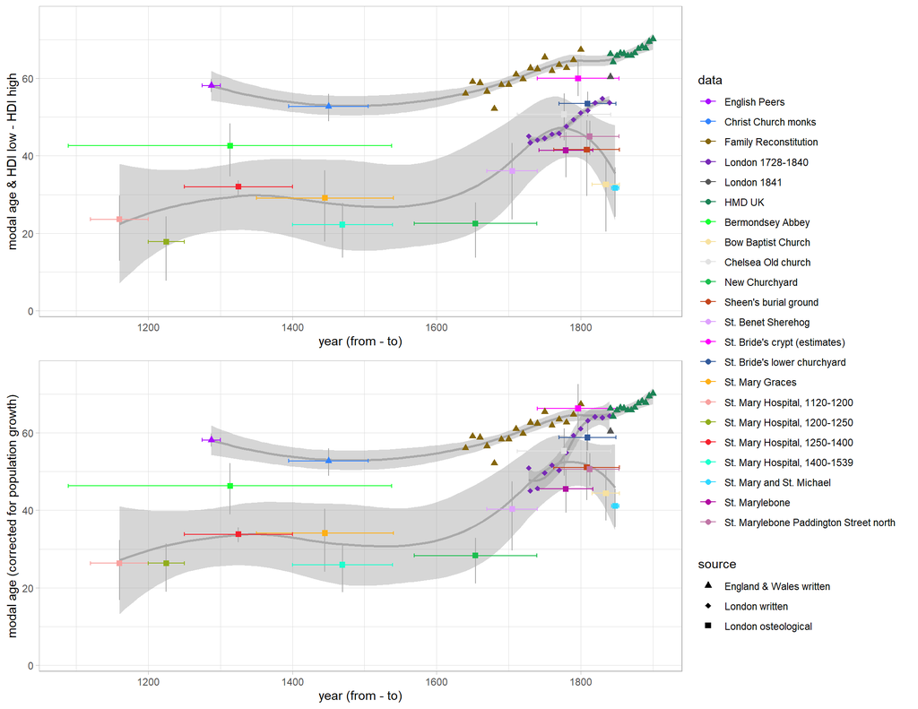

```r
# get symbols & colors from palette alphabet (max n = 26), alt. glasbey (32), polychrome(36)
plotcolors<-palette.colors(palette = 'alphabet')
plotsymbols<-c(17,18,15)

# MOLA Welcome data without correction of population growth
english_wellcome <- rbind(english_mortality_prep, wellcome_prep)

# slight modifications
english_wellcome <- english_wellcome %>%
  mutate(data = factor(data, levels = unique(data))) %>%
  mutate(source = gsub('written','England & Wales written', source)) %>%
  mutate(source = gsub('osteological','London osteological', source)) %>%
  mutate(source = ifelse(data=="London 1728-1840","London written",source)) %>%
  mutate(source = factor(source, levels = c('England & Wales written', 'London written',
                         'London osteological'))) %>%
  mutate(start = as.numeric(start)) %>%
  mutate(end = as.numeric(end)) %>%
  mutate(year = ifelse(is.na(year), (start + end)/2, substr(year, 2,5))) %>%
  mutate(year = as.numeric(year))

ggplot(english_wellcome, aes(x = year, y = M, colour = data, shape = source) ) +
  ylab("modal age & HDI low - HDI high")  +
  xlab("year (from - to)") + ylim(2, 75) + theme_light() +
  scale_color_manual(values=unname(plotcolors)) +
  scale_shape_manual(values=plotsymbols) +
  geom_smooth(color = "dark grey", method = 'loess', formula = 'y ~ x') +
  geom_errorbar(aes(ymin = HDIlow, ymax=  HDIhigh), width=0, colour = "dark grey") +
  geom_errorbarh(aes(xmax = start, xmin = end, height = 1)) +
  geom_point(size= 2 ) +
  guides(size = "none",colour=guide_legend(ncol=1)) +
  scale_x_continuous (breaks = seq(1200, 1800, by = 200)) +
  theme(legend.position="none") -> english_wellcome_plot

# MOLA Welcome data with correction of population growth (_r)
english_wellcome_r <- rbind(english_mortality_prep_r, wellcome_prep_r)

# slight modifications
english_wellcome_r <- english_wellcome_r %>%
  mutate(data = factor(data, levels = unique(data))) %>%
  mutate(source = gsub('written','England & Wales written', source)) %>%
  mutate(source = gsub('osteological','London osteological', source)) %>%
  mutate(source = ifelse(data=="London 1728-1840","London written",source)) %>%
  mutate(source = factor(source, levels = c('England & Wales written', 'London written',
                         'London osteological'))) %>%
  mutate(start = as.numeric(start)) %>%
  mutate(end = as.numeric(end)) %>%
  mutate(year = ifelse(is.na(year), (start + end)/2, substr(year, 2,5))) %>%
  mutate(year = as.numeric(year))

ggplot(english_wellcome_r, aes(x = year, y = M, colour = data, shape = source) ) +
  ylab("modal age (corrected for population growth)")  +
  xlab("year (from - to)") + ylim(2, 75) + theme_light() +
  scale_color_manual(values=unname(plotcolors)) +
  scale_shape_manual(values=plotsymbols) +
  geom_smooth(color = "dark grey", method = 'loess', formula = 'y ~ x') +
  geom_errorbar(aes(ymin = HDIlow, ymax=  HDIhigh), width=0, colour = "dark grey") +
  geom_errorbarh(aes(xmax = start, xmin = end, height = 1)) +
  geom_point(size= 2 )+
  guides(size = "none",colour=guide_legend(ncol=1)) +
  scale_x_continuous (breaks = seq(1200, 1800, by = 200)) -> english_wellcome_plot_r

# get the legend and remove it afterwards
ewp_legend <- get_legend(english_wellcome_plot_r)
english_wellcome_plot_r <- english_wellcome_plot_r + theme(legend.position="none")

# build the image
grid::grid.newpage()
ewp<-plot_grid(english_wellcome_plot, english_wellcome_plot_r, ncol=1)
modal_ages_plot <- plot_grid(ewp, ewp_legend, ncol = 2, rel_widths = c(.75, .25))

# Save the finished map object
ggsave(
  filename = "fig06_modal_ages_plot.pdf",
  width = 11, height = 8.5,
  plot = modal_ages_plot,
  device = "pdf",
  path = "documented"
)

plot(modal_ages_plot)
```

The following data overview is build during pre-processing in ./chapter_04_results/Wellcome_DB.R and saved to a textfile (sep = \t).

### Table 3: Major cemeteries of London, without and with (r) compensation of population growth. beta – Gompertz beta parameter; M – modal age; ex20 – life expectancy at age 20; ex25 – life expectancy at age 25. Ranges computed with credible HDIs of 95%.

```r
kable(wellcome_overview_all) %>%
  kableExtra::kable_styling(latex_options = c("HOLD_position","scale_down"))
```

| cemetery | beta | beta_range | M | M_range | ex20 | ex25 | r_beta | r_beta_range | r_M | r_M_range | r_ex20 | r_ex25 |
| --- | --- | --- | --- | --- | --- | --- | --- | --- | --- | --- | --- | --- |
| Bermondsey Abbey | 0.0414 | 0.0319-0.0504 | 42.6 | 34.7-48.4 | 25.5 | 22.7 | 0.0439 | 0.0337-0.0529 | 46.3 | 38.9-52.2 | 27.1 | 24.1 |
| Bow Baptist Church | 0.0345 | 0.026-0.0429 | 32.6 | 20.4-39.4 | 22.7 | 20.4 | 0.0410 | 0.0318-0.0497 | 44.4 | 37.3-50.4 | 26.9 | 24.0 |
| Chelsea Old church | 0.0422 | 0.0328-0.0518 | 50.7 | 44-56.1 | 30.4 | 27.3 | 0.0458 | 0.0348-0.0557 | 55.3 | 48.9-61.2 | 33.1 | 29.6 |
| New Churchyard | 0.0365 | 0.0299-0.0432 | 22.5 | 13.7-27.9 | 17.0 | 15.0 | 0.0398 | 0.0331-0.0467 | 28.3 | 21.1-32.9 | 18.5 | 16.3 |
| Sheen’s burial ground | 0.0350 | 0.0263-0.0447 | 41.6 | 29.6-49.1 | 27.3 | 24.6 | 0.0407 | 0.0305-0.0508 | 51.1 | 42.6-58.3 | 31.3 | 28.2 |
| St. Benet Sherehog | 0.0353 | 0.0265-0.0446 | 36.1 | 23.6-43.3 | 23.7 | 21.2 | 0.0378 | 0.0283-0.0473 | 40.3 | 29.6-47.5 | 25.4 | 22.7 |
| St. Bride’s crypt (estimates) | 0.0455 | 0.0377-0.0547 | 60.0 | 55.4-64.7 | 36.8 | 33.2 | 0.0494 | 0.0384-0.0598 | 66.3 | 60.7-72.6 | 41.2 | 37.3 |
| St. Bride’s crypt (known age) | 0.0491 | 0.0423-0.0565 | 59.4 | 55.5-62.5 | 35.7 | 32.0 | 0.0547 | 0.0477-0.062 | 63.8 | 60.7-66.4 | 38.4 | 34.5 |
| St. Bride’s lower churchyard | 0.0511 | 0.0424-0.0599 | 53.5 | 50.2-56.6 | 31.0 | 27.5 | 0.0577 | 0.0483-0.0669 | 58.8 | 55.3-62.9 | 34.6 | 30.7 |
| St. Mary Graces | 0.0349 | 0.0267-0.0427 | 29.1 | 17.8-36.2 | 20.8 | 18.6 | 0.0372 | 0.0288-0.0455 | 34.1 | 24.1-40.4 | 22.2 | 19.8 |
| St. Mary Hospital, 1120-1200 | 0.0366 | 0.0289-0.0437 | 23.6 | 12.9-29.7 | 17.4 | 15.4 | 0.0382 | 0.0304-0.0454 | 26.3 | 16.8-32.3 | 18.0 | 15.9 |
| St. Mary Hospital, 1200-1250 | 0.0355 | 0.0289-0.0424 | 17.8 | 7.7-24.3 | 15.7 | 13.8 | 0.0399 | 0.0328-0.0467 | 26.3 | 18.9-31.4 | 17.4 | 15.3 |
| St. Mary Hospital, 1250-1400 | 0.0577 | 0.0529-0.0634 | 32.0 | 30-33.6 | 16.0 | 13.4 | 0.0608 | 0.0556-0.0665 | 33.8 | 31.7-35.6 | 16.5 | 13.8 |
| St. Mary Hospital, 1400-1539 | 0.0374 | 0.0307-0.0443 | 22.2 | 13.7-27.8 | 16.7 | 14.7 | 0.0400 | 0.0329-0.0467 | 25.9 | 18.8-31.3 | 17.4 | 15.3 |
| St. Mary and St. Michael | 0.0405 | 0.0323-0.0482 | 31.7 | 24.2-37 | 20.0 | 17.6 | 0.0460 | 0.0378-0.0542 | 41.1 | 35.7-45.5 | 23.4 | 20.6 |
| St. Marylebone | 0.0423 | 0.0331-0.0508 | 41.4 | 34.4-46.1 | 24.5 | 21.7 | 0.0452 | 0.0358-0.0541 | 45.5 | 39.4-50.5 | 26.7 | 23.7 |
| St. Marylebone Paddington Street north | 0.0486 | 0.0399-0.0578 | 45.0 | 40.2-49 | 25.4 | 22.4 | 0.0538 | 0.0448-0.0633 | 50.6 | 46.3-54.8 | 28.8 | 25.4 |

```r
write.table(wellcome_overview_all, file = "./documented/table02_osteological_estimates.txt",
            sep="\t", quote = FALSE)
```

Data are hard coded in the code. Sources: Miles, Powers, et al. (2008), 97–103 table 32 (St Marylebone); Henderson et al. (2015), 81 (St Marylebone north of Paddington street)

```r
source("./lifetables_processing/Marylebone.R")
kable(Marylebone_ranges,
      caption = "St Marylebone, corrected with population growth rate of 2.75 per-cent.") %>%
  kableExtra::kable_styling(latex_options = "HOLD_position")
```

St Marylebone, corrected with population growth rate of 2.75 per-cent.

| parameter | modes | HDI.ranges |
| --- | --- | --- |
| Marylebone beta | 0.0527 | 0.0433-0.0619 |
| Marylebone M | 54.4880 | 49.6-59.3 |
| Marylebone north beta | 0.0593 | 0.0499-0.0685 |
| Marylebone north M | 55.3931 | 51.4-59.9 |

The following plot is build in ./lifetables_processing/stbrides_crypt.R within the if-statement on `runCodeNew` (s. data limitations above).

### Figure 9: St. Bride’s Crypt. Density of actual ages and Bayesian model of Gompertz distribution of actual ages and osteological estimates (without correction for population growth).

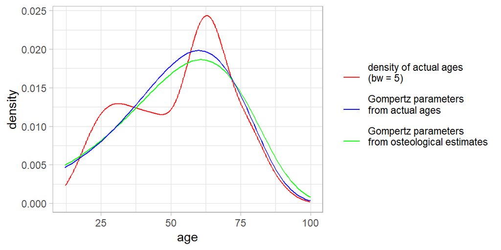

```r
plot(stbrides_crypt_plot)
```

### Figure 10: Simulation of population increase with known age-at-death and Maximum Likelihood Estimation (MLE) (top four) and osteological estimates, Bayesian model and including rate of increase (bottom four).

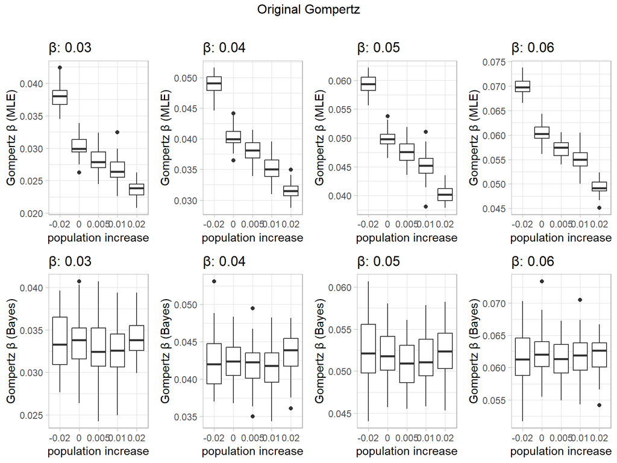

```r
if (runCodeNew){
  set.seed(3673)
  lt_sim_list <- list()
  for(k in 1:4) {
    lt_sim <- lt.MC.Gomp(pop_start = c(10000, 1000, 500, 200, 100),
                         pop_inc = c(-0.02, 0, 0.005, 0.01, 0.02),
                         years = 200,
                         obs_start = 150,
                         obs_end = 200,
                         beta = (k + 2)/100,
                         bayes = TRUE)
    lt_sim_list[[k]] <- lt_sim
  }

  # saves results in Rda-object
  save(lt_sim_list, file = file.path(".", saveFileDir, "lt_sim_list.Rda") )
}
load(file.path(".", saveFileDir, "lt_sim_list.Rda") )

lt_sim_plot_list <- list()
for (i in 1:4) {
lt_sim_plot_list[[i]] <- ggplot(lt_sim_list[[i]],
                                aes(y = surv_Gompertz_shape,
                                    x = as.factor(pop_inc))) +
  geom_boxplot()  +
  ggtitle(paste0("\u03B2: ", (i + 2)/100) ) +
  ylab("Gompertz \u03B2 (MLE)") + xlab("population increase") +
  theme(plot.margin = unit(c(0,0.5,0.5,0), "cm"),
        plot.title = element_text(size = 12),
        axis.title = element_text(size = 10),
        axis.text = element_text(size = 8)) + theme_light()
lt_sim_plot_list[[i + 4]] <-   ggplot(lt_sim_list[[i]],
                                      aes(y = bayes_gomp_b,
                                          x = as.factor(pop_inc)) ) +
  geom_boxplot()  +
  ggtitle(paste0("\u03B2: ", (i + 2)/100) ) +
  ylab("Gompertz \u03B2 (Bayes)") + xlab("population increase") +
  theme(plot.margin = unit(c(0,0.5,0.5,0), "cm"),
              plot.title = element_text(size = 12),
              axis.title = element_text(size = 10),
              axis.text = element_text(size = 8)) + theme_light()
}

lt_sim_plots <- gridExtra::grid.arrange (grobs = lt_sim_plot_list, ncol = 4,
                                         top = textGrob("Original Gompertz\n",
                                                        gp=gpar(fonsize = 14)))
```

```r
# Save the finished map object
ggsave(
  filename = "fig08_lt_sim_plots.pdf",
  width = 11.5, height = 8,
  plot = lt_sim_plots,
  device = cairo_pdf,
  path = "documented"
)
```

# Supporting information

## The Coale & Demeny life tables

Calculation of the lowest $\beta$-value for any of the Coale & Demeny life tables (Coale & Demeny (1983)) which is 0.0391 (the female table “West”, level 1).

```r
source("./chapter_supplement/coale_demeny_life_tables_gompertz.R")
min(gompertz_df$Gompertz_shape)
```

```
## [1] 0.03913138
```

## Simulations

### S.Fig 1: Bayesian model of simulated data with anthropological age categories and random error in “age estimation.” Difference of estimated to original Gompertz $\beta$ in relation to original $\beta$ (left) and sample size (right).

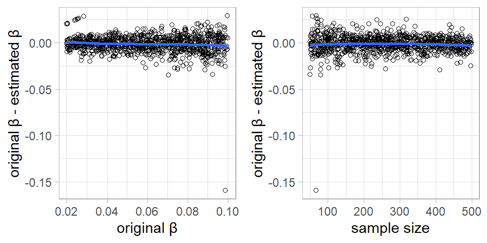

```r
#source("./chapter_supplement/simulations_run.R")
gridExtra::grid.arrange(grobs = plot_list_bayes_diff, ncol = 2)
```

### S.T.1. Bayesian model with simulated data-set to compare the impact of thinning and additional steps. n = 500, Gompertz $\beta$ = 0.05.

```r
source("./chapter_supplement/bayes_complete.R") # can take a few minutes
kable (bayes_complete) %>%
  kableExtra::kable_styling(latex_options = c("HOLD_position","scale_down"))
```

| mode | thinning | steps | parameter | PSRF Point est. | PSRF Upper C.I. | Mean | Median | Mode | ESS | MCSE | HDImass | HDIlow | HDIhigh |
| --- | --- | --- | --- | --- | --- | --- | --- | --- | --- | --- | --- | --- | --- |
| known_age | 1 | 10000 | a | 1.003210 | 1.006108 | 0.0028582 | 0.0028441 | 0.0027725 | 462.7 | 0.0000154 | 0.95 | 0.0022403 | 0.0035193 |
| known_age | 1 | 10000 | b | 1.001893 | 1.003920 | 0.0480363 | 0.0480265 | 0.0481745 | 488.6 | 0.0000947 | 0.95 | 0.0440097 | 0.0520917 |
| known_age | 1 | 10000 | M | 1.001259 | 1.003216 | 73.8375371 | 73.8501409 | 73.6934420 | 930.5 | 0.0357533 | 0.95 | 71.6915433 | 75.9608132 |
| known_age | 20 | 100000 | a | 1.000011 | 1.000109 | 0.0028495 | 0.0028327 | 0.0027934 | 71982.2 | 0.0000013 | 0.95 | 0.0022163 | 0.0035260 |
| known_age | 20 | 100000 | b | 1.000005 | 1.000090 | 0.0480993 | 0.0480962 | 0.0483082 | 71181.0 | 0.0000080 | 0.95 | 0.0438344 | 0.0521777 |
| known_age | 20 | 100000 | M | 1.000000 | 1.000078 | 73.8543153 | 73.8768307 | 73.9884330 | 84071.3 | 0.0037849 | 0.95 | 71.6339091 | 75.9294081 |
| estimation | 1 | 10000 | a | 1.007384 | 1.023678 | 0.0028312 | 0.0028026 | 0.0027942 | 167.5 | 0.0000382 | 0.95 | 0.0019049 | 0.0038193 |
| estimation | 1 | 10000 | b | 1.011691 | 1.038693 | 0.0510970 | 0.0508290 | 0.0503803 | 86.5 | 0.0005942 | 0.95 | 0.0404465 | 0.0624583 |
| estimation | 1 | 10000 | M | 1.005548 | 1.017117 | 71.9242579 | 71.9119671 | 72.0531786 | 392.2 | 0.1119194 | 0.95 | 67.6950056 | 76.3291669 |
| estimation | 20 | 100000 | a | 1.000247 | 1.000941 | 0.0027769 | 0.0027509 | 0.0027034 | 29177.9 | 0.0000026 | 0.95 | 0.0019290 | 0.0036726 |
| estimation | 20 | 100000 | b | 1.000354 | 1.001342 | 0.0516959 | 0.0514776 | 0.0502964 | 20843.0 | 0.0000356 | 0.95 | 0.0421542 | 0.0619696 |
| estimation | 20 | 100000 | M | 1.000091 | 1.000334 | 71.8362699 | 71.7754410 | 71.6155191 | 45976.8 | 0.0102799 | 0.95 | 67.6297829 | 76.2104655 |

# References

Coale, A. J., & Demeny, P. (1983). *Regional model life tables and stable populations*. New York: Academic Press.

Connell, B., Gray Jones, A., Redfern, R., & Walker, D. (2012). *A bioarchaeological study of medieval burials on the site of St Mary Spital: Excavations at Spitalfields Market, London E1, 1991–2007* (pp. XX, 303; Connell. Brian, Ed.). London: Museum of London Archaeology.

Cowie, R., Bekvalac, J., & Kausmally, T. (2008). *Late 17th- to 19th-century burial and earlier occupation at All Saints, Chelsea Old Church, Royal Borough of Kensington and Chelsea* (pp. xii, 69). London: Museum of London Archaeology Service.

Dyson, T., Samuel, M., Steele, A., & Wright, S. M. (2011). *The Cluniac priory and abbey of St Saviour, Bermondsey, Surrey: Excavations 1984–95* (pp. XVII, 297). London: Museum of London Archaeology.

Finlay, R., & Shearer, B. (1986). London 1500–1700: The making of the metropolis. In A. L. Beier & R. Finlay (Eds.), *Population growth and suburban expansion*: *Vol.* *Population growth and suburban expansion* (pp. 37–59). London, New York: Longman.

Graham, G. (1842). *Fourth Annual Report of the Registrar-General of Births, Deaths, and Marriages in England*. London: W. Clowes; Sons.

Grainger, I., & Phillpotts, C. (2011). *The Cistercian abbey of St Mary Graces, East Smithfield, London* (pp. XV, 204; G. Ian & C. Phillpotts, Eds.). London: Museum of London Archaeology Service.

Hartle, R., Carty, N., Henderson, M., Knox, E. L., & Walker, D. (2017). *The New Churchyard: From Moorfields Marsh to Bethlem burial ground, Brokers Row and Liverpool Street*. London: Museum of London Archaeology.

Hatcher, J., Piper, A. J., & Stone, D. (2006). Monastic mortality: Durham Priory, 1395–1529. *The Economic History Review*, *59*(4), 667–687. https://doi.org/10.1111/j.1468-0289.2006.00364.x

Henderson, M., Miles, A., & Walker, D. (2013). *’He being dead yet speaketh‘: Excavations at three post-medieval burial grounds in Tower Hamlets, east London, 2004–10* (pp. XXIII, 330). London: Museum of London Archaeology.

Henderson, M., Walker, D., & Miles, A. (2015). *St Marylebone’s Paddington Street north burial ground: Excavations at Paddington Street, London W1, 2012-13* (pp. xiii, 135 Seiten; A. M. Michael Henderson & D. Walker, Eds.). London: Museum of London Archaeology.

Kausmally, T. (2008). *St. Bride’s lower churchyard cemetery summary*.

La Poutré, H. J. P., & Janssen, F. (2021). A two-parameter hazard function to describe age patterns of mortality in ancient Northwestern Europe. *Genus*, *77*, 1–21. https://doi.org/10.1186/s41118-021-00122-w

Landers, J. (1993). *Death and the metropolis: Studies in the demographic history of London, 1670-1830* (pp. 1 Online–Ressource (xxiii, 408 pages)). London: Cambridge University Press.

Miles, A., Powers, N., Wroe-Brown, R., & Walker, D. (2008). *St Marylebone Church and burial ground in the 18th to 19th centuries: Excavations at St Marylebone School, 1992 and 2004–6.* (pp. XIV, 172; M. N. P. Adrian & R. W.-B. with Don Walker, Eds.). London: Museum of London Archaeology Service.

Miles, A., White, W. J., & Tankard, D. (2008). *Burial at the site of the parish church of St Benet Sherehog before and after the Great Fire: Excavations at 1 Poultry, City of London* (pp. XII, 114). London: Museum of London Archaeology Service.

Plummer, M. (2003). JAGS: A Program for Analysis of Bayesian Graphical Models Using Gibbs Sampling. In K. Hornik, F. Leisch, & A. Zeileis (Eds.), *Proceedings of the 3rd International Workshop on Distributed Statistical Computing (DSC 2003), Vienna, 20-22 March 2003*: *Vol.* *Proceedings of the 3rd International Workshop on Distributed Statistical Computing (DSC 2003), Vienna, 20-22 March 2003* (pp. 1–10). Wien: Technische Universität Wien.

Razzell, P., & Spence, C. (2007). The history of infant, child and adult mortality in London, 1550–1850. *The London Journal*, *32*(3), 271–292. https://doi.org/10.1179/174963207X227578

Roberts, C. A., & Cox, M. (2003). *Health and disease in Britain from prehistory to the present day* (pp. XIX, 476 S). Stroud: Sutton.

Scheuer, J. L. (1995). Correlation of documentary and skeletal evidence in the St. Bride’s crypt population. In S. R. Saunders & A. Herring (Eds.), *Grave reflection: Portraying the past through cemetery studies*: *Vol.* *Grave reflection: Portraying the past through cemetery studies* (pp. 49–70). Toronto: Canadian Scholars’ Press.

Scheuer, L. (1998). Age at death and cause of death of the people buried in St Bride’s Church, Fleet Street, London. In M. Cox (Ed.), *Grave concerns: death and burial in England 1700 to 1850*: *Vol.* *Grave concerns: death and burial in England 1700 to 1850* (pp. 100–111). York: Council for British Archaeology.

Weinreb, B., Hibbert, C., Keay, J., & Keay, J. (2008). *The London encyclopaedia* (pp. XVI, 1100; W. C. Hibbert. N. photographs by M. W. Ben, Ed.). London: Macmillan.

Wrigley, E. A., Oeppen, J. E., Davies, R. S., & Schofield, R. S. (1997). *English Population History from Family Reconstitution 1580–1837*. Cambridge: Cambridge University Press.

[^1]: Institute for Prehistoric and Protohistoric Archaeology - Kiel University nils.mueller-scheessel@ufg.uni-kiel.de
[^2]: Institute for Prehistoric and Protohistoric Archaeology - Kiel University, k.fuchs@ufg.uni-kiel.de
[^3]: Institute for Prehistoric and Protohistoric Archaeology - Kiel University, crinne@ufg.uni-kiel.de